# 🧪 Demonstration: MIDRC BIH Federated Data Mesh (Pilot Notebook)

> **Purpose.** This notebook showcases a compact, end-to-end **federated analysis** workflow—spanning **discovery → access → harmonization → representation learning → evaluation → reporting**—to illustrate how the **MIDRC Biomedical Informatics Hub (BIH)** enables cross-repository research without centralizing raw data.

## 🎯 Objectives

- **Query** at least two datasets located in **separate, BIH-interoperable repositories**  
  *(we use Stanford **Stanford AIMI MRA-MIDAS** and **TCIA CPTAC-CM** as “low-hanging fruit”)*
- **Pull** subsets into a **MIDRC BIH workspace** for analysis & visualization
- **Harmonize** with granular metadata, **Common Data Elements (CDEs)**, and the **MIDRC Common Data Model (CDM)**  
  *(with hooks to integrate **BDF** harmonization tools as they mature)*

## 🧰 Datasets & Access

| Source | Modality | Access | Content (pilot) | Notes |
| --- | --- | --- | --- | --- |
| **Stanford AIMI MRA-MIDAS (Stanford)** | Dermoscopic/clinical photos | SAS URL (read-list) | ✓ | Excel metadata + image files |
| **TCIA CPTAC-CM** | CT / MR / PT (DICOM) | NBIA v1/v4 APIs | ✓ | Rich DICOM tags; series/instance granularity |

Both are accessed **in place** via public endpoints; only **manifests** and **pilot subsets** are staged in the BIH workspace.

## 🗺️ Workflow Overview

1. **Discovery & Access**
   - Enumerate TCIA series via **NBIA API** (v1 JSON/CSV fallback to v4).
   - Enumerate AIMI blobs via SAS; stage a **pilot** set.
2. **Workspace Pull**
   - Download a small, representative sample from each source.
   - Build **manifests**:
     - `midas_manifest.csv` (images, lesion IDs, diagnosis bin)
     - `cptac_cm_png_manifest.json` (series UID, modality, body part, PNG previews, captions)
3. **Harmonization (BIH/MIDRC)**
   - Normalize **identifiers** (`series_uid`, `patient_id`, `lesion_id`) and key fields (`modality`, `body_part`, `series_desc`).
   - Map to **CDE/CDM-like** columns; preserve **provenance** (source, file paths, access route).
   - Provide **plug-points** for **BDF** harmonizers/CDM mappers.
4. **Representation Learning**
   - **CLIP (ViT-B/32)** embeddings for MIDAS photos (512-D).
   - **ResNet50** features (2048-D) for TCIA slices → window/normalize → PNG reps.
   - **Ridge map** from radiology→CLIP-text space using auto-generated captions; normalize to 512-D.
5. **Shared Space & Visualization**
   - **PCA → 128-D** shared space (optionally append label anchors).
   - **Fast UMAP** for 2-D projection (subset-fit + transform); qualitative panels (top/bottom series).
6. **Evaluation & Reporting**
   - Train **Logistic Regression** on MIDAS (5-fold **AUROC/PR-AUC**; **calibration** + **permutation test**).
   - Score CPTAC series; summarize distributions by **modality** / **body part** with bootstrap CIs.
   - Emit figures, tables, and a compact **final report** (`outputs/final_report.md`).

## 🧱 What “Harmonization” Means Here

- Aligns identifiers & semantics to BIH/MIDRC expectations.
- Preserves **traceability** (raw paths, access pattern, source metadata).
- Stays **tool-agnostic**, so you can swap in **BDF** utilities and CDM mappers with minimal refactoring.

> 💡 **Design Choice:** Keep manifests **simple & auditable** (CSV/JSON) so they are easy to diff, share, and reproduce across BIH workspaces.

## 📦 Expected Artifacts

- **Manifests:** `midas_manifest.csv`, `cptac_cm_png_manifest.json`, pilot DICOM CSV
- **Embeddings:** `midas_clip_img_512.npy`, `cptac_resnet50_2048.npy`, mapped `cptac_clip_mapped_512.npy`
- **Shared Space:** `midas_128.npy`, `cptac_128.npy`
- **Models & Scores:** `midas_calibrated_lr.joblib`, `cptac_scores_calibrated.csv`
- **Diagnostics:** UMAP plots, histograms, reliability & permutation figures
- **Report:** `outputs/final_report.md`

## ✅ Ready-to-Run Checklist

- [ ] Access confirmed for **AIMI SAS URL** (valid `se`, `sig`)
- [ ] TCIA **NBIA API** reachable (v1 JSON/CSV or v4 fallback)
- [ ] Python env meets requirements (NumPy/Sklearn/PyTorch/Open-CLIP; pinned where needed)
- [ ] Sufficient local disk for pilot PNGs/DICOMs and embeddings
- [ ] (Optional) **BDF** harmonization tools available in path

## ⚠️ Scope & Limitations (Pilot)

- Small, curated subsets for speed; **not** a benchmark.
- Simple models (CLIP + linear/ridge/logistic); upgrade to **modality-aware encoders** and **subject-level CV** as next steps.
- No PHI; all access adheres to repository governance.

## ✨ Takeaway

This notebook demonstrates how a **BIH-style federated mesh** lets you **compose** multi-repository, multi-modality analyses by standardizing **metadata & CDEs**, keeping **provenance**, and enabling repeatable, workspace-local compute—without moving the world’s data.

## Fetch CPTAC-CM series list from TCIA (robust to API variants)

**Goal.** Retrieve all imaging **series** for the `CPTAC-CM` collection from TCIA, handling multiple API paths and formats so the notebook keeps working even if one endpoint changes.

- Collection: `CPTAC-CM`
- Base endpoint: `https://services.cancerimagingarchive.net/`

### Method (fallback order)

1. **NBIA v1 – JSON**  
   `.../nbia-api/services/v1/getSeries?Collection=CPTAC-CM&format=json`
2. **NBIA v1 – CSV**  
   `.../nbia-api/services/v1/getSeries?Collection=CPTAC-CM&format=csv`
3. **TCIA v4 – JSON (fallback)**  
   `.../services/v4/TCIA/query/getSeries?Collection=CPTAC-CM&format=json`

The function tries each path in order and returns the first successful response as a pandas `DataFrame`, along with a short tag indicating which path succeeded (e.g., `v1/json`).

### Key columns (used later)

- `SeriesInstanceUID` *(primary key)*
- `StudyInstanceUID`, `Modality`, `SeriesDate`, `SeriesDescription`, `BodyPartExamined`, `SeriesNumber`, `ImageCount`
- `Manufacturer`, `ManufacturerModelName`, `SoftwareVersions`
- `LicenseURI`, `CollectionURI`, `DateReleased`

### Outputs

- Console message: `CPTAC-CM: <N> series via <path_used>`
- Preview of the first 3 rows (schema sanity check)

### Why this matters

A robust, schema-stable **series table** ensures downstream steps—DICOM→PNG conversion, stratified summaries, and scoring—can reliably join on `SeriesInstanceUID` without breaking when an API format changes.

```python
# === 0) Imports & setup ===
import io, zipfile, requests, pandas as pd
from pathlib import Path
from tqdm.auto import tqdm
import os, time, zipfile, re, math
from requests.adapters import HTTPAdapter
from urllib3.util.retry import Retry
from urllib.parse import urlparse, parse_qsl
from concurrent.futures import ThreadPoolExecutor, as_completed
from xml.etree import ElementTree as ET
import json, numpy as np
from PIL import Image
import pydicom
import open_clip
import json, torch, timm
from torchvision import transforms
from sklearn.decomposition import PCA
import umap
import matplotlib.pyplot as plt
from sklearn.neighbors import NearestNeighbors
from sklearn.model_selection import StratifiedKFold
from sklearn.linear_model import LogisticRegression, Ridge
from sklearn.preprocessing import StandardScaler
from sklearn.pipeline import make_pipeline
from sklearn.metrics import roc_auc_score, average_precision_score, brier_score_loss
from sklearn.calibration import calibration_curve
from sklearn.calibration import CalibratedClassifierCV
from scipy import stats
import joblib, random


TCIA_V1 = "https://services.cancerimagingarchive.net/nbia-api/services/v1"
COLLECTION = "CPTAC-CM"
OUT = Path("./").resolve(); OUT.mkdir(parents=True, exist_ok=True)
```

```python
def get_series_any(collection):
    # v1 JSON
    r = requests.get(f"{TCIA_V1}/getSeries",
                     params={"Collection": collection, "format":"json"}, timeout=120)
    if r.ok and r.text.strip():
        try:
            return pd.DataFrame(r.json()), "v1/json"
        except Exception:
            pass
    # v1 CSV
    r = requests.get(f"{TCIA_V1}/getSeries",
                     params={"Collection": collection, "format":"csv"}, timeout=120)
    if r.ok and r.text.strip():
        try:
            return pd.read_csv(io.StringIO(r.text)), "v1/csv"
        except Exception:
            pass
    # v4 JSON
    r = requests.get("https://services.cancerimagingarchive.net/services/v4/TCIA/query/getSeries",
                     params={"Collection": collection, "format":"json"}, timeout=120)
    r.raise_for_status()
    return pd.DataFrame(r.json()), "v4/json"

series_df, path_used = get_series_any(COLLECTION)
print(f"{COLLECTION}: {len(series_df)} series via {path_used}")
series_df.head(3)
```

```
CPTAC-CM: 186 series via v1/json
```

|  | SeriesInstanceUID | StudyInstanceUID | Modality | SeriesDate | SeriesDescription | BodyPartExamined | SeriesNumber | Collection | PatientID | ImageCount | ... | LicenseURI | CollectionURI | FileSize | DateReleased | StudyDesc | StudyDate | ProtocolName | Manufacturer | ManufacturerModelName | SoftwareVersions |
| --- | --- | --- | --- | --- | --- | --- | --- | --- | --- | --- | --- | --- | --- | --- | --- | --- | --- | --- | --- | --- | --- |
| 0 | 1.3.6.1.4.1.14519.5.2.1.3320.3273.107577632221... | 1.3.6.1.4.1.14519.5.2.1.3320.3273.226973017455... | PT | 2000-12-20 00:00:00.0 | PET Statistics | WHOLEBODY | 5 | CPTAC-CM | C3N-02633 | 4 | ... | http://creativecommons.org/licenses/by/3.0/ | https://doi.org/10.7937/K9/TCIA.2018.ODU24GZE | 2105896 | 2020-06-30 00:00:00.0 | PET^WHOLEBODY_LD90 (Adult) | 2000-12-20 00:00:00.0 | NaN | NaN | NaN | NaN |
| 1 | 1.3.6.1.4.1.14519.5.2.1.3320.3273.486914768716... | 1.3.6.1.4.1.14519.5.2.1.3320.3273.191540915697... | PT | 2000-12-15 00:00:00.0 | PET Statistics | WHOLEBODY | 5 | CPTAC-CM | C3N-02679 | 4 | ... | http://creativecommons.org/licenses/by/3.0/ | https://doi.org/10.7937/K9/TCIA.2018.ODU24GZE | 2105920 | 2020-06-30 00:00:00.0 | PET^WHOLEBODY_LONG_LD90 (Adult) | 2000-12-15 00:00:00.0 | NaN | NaN | NaN | NaN |
| 2 | 1.3.6.1.4.1.14519.5.2.1.2932.1975.126887613559... | 1.3.6.1.4.1.14519.5.2.1.2932.1975.266776623721... | CT | 2010-05-06 00:00:00.0 | CONTRAST | NaN | 6 | CPTAC-CM | C3N-03614 | 1051 | ... | http://creativecommons.org/licenses/by/3.0/ | https://doi.org/10.7937/K9/TCIA.2018.ODU24GZE | 555277494 | 2019-06-30 00:00:00.0 | CHEST ABDOMEN | 2010-05-06 00:00:00.0 | 6.3 3 Phases Liver | GE MEDICAL SYSTEMS | LightSpeed16 | 07MW11.10 |

3 rows × 22 columns

### Modalities present in CPTAC-CM

We sanity-check the series table by listing unique values of `Modality`.  
Result: `['PT', 'CT', 'MR']` — i.e., the collection contains PET, CT, and MR series.

```python
series_df.Modality.unique()
```

```
array(['PT', 'CT', 'MR'], dtype=object)
```

### Select a manageable sample (and optionally filter by modality)

1. **Find the modality column (case-insensitive).**  
   The code looks for `"Modality"` (or `"modality"`). If present, `mod_col` stores its name; otherwise it’s `None`.
2. **Optional: keep only WSI (SM) if available.**  
   If a modality column exists, we uppercase/strip its values and keep only rows where the modality equals **`"SM"`**.
   - If such rows exist, we replace `series_df` with this WSI subset and print its size.
   - If there is no modality column (or no SM rows), we print a note and continue with **all** series.
3. **Preview a small batch.**  
   We take the first **8** series (`head(8)`) as a manageable sample for downstream steps.
4. **Display key identifiers (and modality if present).**  
   We show `SeriesInstanceUID`, `StudyInstanceUID`, and, when available, the `Modality` column to sanity-check the selection.

```python
mod_col = "Modality" if "Modality" in series_df.columns else ("modality" if "modality" in series_df.columns else None)
if mod_col:
    sm_df = series_df[series_df[mod_col].astype(str).str.upper().str.strip().eq("SM")]
    if len(sm_df) > 0:
        series_df = sm_df
        print("Using WSI (SM) subset:", len(series_df))
else:
    print("No modality column found; proceeding with all series.")

# keep a manageable sample first (you can raise this later)
pick_df = series_df.head(8)
pick_df[["SeriesInstanceUID","StudyInstanceUID",mod_col] if mod_col else ["SeriesInstanceUID","StudyInstanceUID"]].head()
```

|  | SeriesInstanceUID | StudyInstanceUID | Modality |
| --- | --- | --- | --- |
| 0 | 1.3.6.1.4.1.14519.5.2.1.3320.3273.107577632221... | 1.3.6.1.4.1.14519.5.2.1.3320.3273.226973017455... | PT |
| 1 | 1.3.6.1.4.1.14519.5.2.1.3320.3273.486914768716... | 1.3.6.1.4.1.14519.5.2.1.3320.3273.191540915697... | PT |
| 2 | 1.3.6.1.4.1.14519.5.2.1.2932.1975.126887613559... | 1.3.6.1.4.1.14519.5.2.1.2932.1975.266776623721... | CT |
| 3 | 1.3.6.1.4.1.14519.5.2.1.2932.1975.307542048144... | 1.3.6.1.4.1.14519.5.2.1.2932.1975.266776623721... | CT |
| 4 | 1.3.6.1.4.1.14519.5.2.1.2932.1975.540568412574... | 1.3.6.1.4.1.14519.5.2.1.2932.1975.266776623721... | CT |

### Inspect the retrieved series table

We display `series_df` to sanity-check the fields returned by TCIA.  
Key columns include:

- **SeriesInstanceUID / StudyInstanceUID** – DICOM identifiers for each series/study
- **Modality** – imaging modality (e.g., PT, CT, MR)
- **SeriesDate / SeriesDescription** – scan date and a brief description
- **BodyPartExamined** – body region (may be missing for some rows)

Use this view to confirm the dataset shape and that essential identifiers and metadata are present before further filtering or sampling.

```python
series_df
```

|  | SeriesInstanceUID | StudyInstanceUID | Modality | SeriesDate | SeriesDescription | BodyPartExamined | SeriesNumber | Collection | PatientID | ImageCount | ... | LicenseURI | CollectionURI | FileSize | DateReleased | StudyDesc | StudyDate | ProtocolName | Manufacturer | ManufacturerModelName | SoftwareVersions |
| --- | --- | --- | --- | --- | --- | --- | --- | --- | --- | --- | --- | --- | --- | --- | --- | --- | --- | --- | --- | --- | --- |
| 0 | 1.3.6.1.4.1.14519.5.2.1.3320.3273.107577632221... | 1.3.6.1.4.1.14519.5.2.1.3320.3273.226973017455... | PT | 2000-12-20 00:00:00.0 | PET Statistics | WHOLEBODY | 5 | CPTAC-CM | C3N-02633 | 4 | ... | http://creativecommons.org/licenses/by/3.0/ | https://doi.org/10.7937/K9/TCIA.2018.ODU24GZE | 2105896 | 2020-06-30 00:00:00.0 | PET^WHOLEBODY_LD90 (Adult) | 2000-12-20 00:00:00.0 | NaN | NaN | NaN | NaN |
| 1 | 1.3.6.1.4.1.14519.5.2.1.3320.3273.486914768716... | 1.3.6.1.4.1.14519.5.2.1.3320.3273.191540915697... | PT | 2000-12-15 00:00:00.0 | PET Statistics | WHOLEBODY | 5 | CPTAC-CM | C3N-02679 | 4 | ... | http://creativecommons.org/licenses/by/3.0/ | https://doi.org/10.7937/K9/TCIA.2018.ODU24GZE | 2105920 | 2020-06-30 00:00:00.0 | PET^WHOLEBODY_LONG_LD90 (Adult) | 2000-12-15 00:00:00.0 | NaN | NaN | NaN | NaN |
| 2 | 1.3.6.1.4.1.14519.5.2.1.2932.1975.126887613559... | 1.3.6.1.4.1.14519.5.2.1.2932.1975.266776623721... | CT | 2010-05-06 00:00:00.0 | CONTRAST | NaN | 6 | CPTAC-CM | C3N-03614 | 1051 | ... | http://creativecommons.org/licenses/by/3.0/ | https://doi.org/10.7937/K9/TCIA.2018.ODU24GZE | 555277494 | 2019-06-30 00:00:00.0 | CHEST ABDOMEN | 2010-05-06 00:00:00.0 | 6.3 3 Phases Liver | GE MEDICAL SYSTEMS | LightSpeed16 | 07MW11.10 |
| 3 | 1.3.6.1.4.1.14519.5.2.1.2932.1975.307542048144... | 1.3.6.1.4.1.14519.5.2.1.2932.1975.266776623721... | CT | 2010-05-06 00:00:00.0 | Reformatted | NaN | 600 | CPTAC-CM | C3N-03614 | 1 | ... | http://creativecommons.org/licenses/by/3.0/ | https://doi.org/10.7937/K9/TCIA.2018.ODU24GZE | 2099820 | 2019-06-30 00:00:00.0 | CHEST ABDOMEN | 2010-05-06 00:00:00.0 | 6.3 3 Phases Liver | GE MEDICAL SYSTEMS | LightSpeed16 | 07MW11.10 |
| 4 | 1.3.6.1.4.1.14519.5.2.1.2932.1975.540568412574... | 1.3.6.1.4.1.14519.5.2.1.2932.1975.266776623721... | CT | 2010-05-06 00:00:00.0 | Recon 2: Pre Contrast | NaN | 4 | CPTAC-CM | C3N-03614 | 485 | ... | http://creativecommons.org/licenses/by/3.0/ | https://doi.org/10.7937/K9/TCIA.2018.ODU24GZE | 256246796 | 2019-06-30 00:00:00.0 | CHEST ABDOMEN | 2010-05-06 00:00:00.0 | 6.3 3 Phases Liver | GE MEDICAL SYSTEMS | LightSpeed16 | 07MW11.10 |
| ... | ... | ... | ... | ... | ... | ... | ... | ... | ... | ... | ... | ... | ... | ... | ... | ... | ... | ... | ... | ... | ... |
| 181 | 1.3.6.1.4.1.14519.5.2.1.3320.3273.398961036320... | 1.3.6.1.4.1.14519.5.2.1.3320.3273.191540915697... | CT | 2000-12-15 00:00:00.0 | CT WB 3.0 B70f | ABDOMEN | 6 | CPTAC-CM | C3N-02679 | 154 | ... | http://creativecommons.org/licenses/by/3.0/ | https://doi.org/10.7937/K9/TCIA.2018.ODU24GZE | 81294484 | 2020-06-30 00:00:00.0 | PET^WHOLEBODY_LONG_LD90 (Adult) | 2000-12-15 00:00:00.0 | WHOLEBODY_LONG_LD90 | NaN | Biograph20 | VG60A |
| 182 | 1.3.6.1.4.1.14519.5.2.1.3320.3273.282769039907... | 1.3.6.1.4.1.14519.5.2.1.3320.3273.191540915697... | CT | 2000-12-15 00:00:00.0 | Topogram 0.6 T80f | ABDOMEN | 1 | CPTAC-CM | C3N-02679 | 1 | ... | http://creativecommons.org/licenses/by/3.0/ | https://doi.org/10.7937/K9/TCIA.2018.ODU24GZE | 527326 | 2020-06-30 00:00:00.0 | PET^WHOLEBODY_LONG_LD90 (Adult) | 2000-12-15 00:00:00.0 | WHOLEBODY_LONG_LD90 | NaN | Biograph20 | VG60A |
| 183 | 1.3.6.1.4.1.14519.5.2.1.3320.3273.302384870243... | 1.3.6.1.4.1.14519.5.2.1.3320.3273.198137444910... | CT | 2001-01-30 00:00:00.0 | Results MM Oncology Reading | CHESTABDOMEN | 1077 | CPTAC-CM | C3N-02270 | 11 | ... | http://creativecommons.org/licenses/by/3.0/ | https://doi.org/10.7937/K9/TCIA.2018.ODU24GZE | 40314184 | 2020-06-30 00:00:00.0 | Abdomen^KlpBrzuchMiednica (Adult) | 2001-01-27 00:00:00.0 | KlpBrzuchMiednica | NaN | syngo.via | syngo.PET&CT Oncology 3.11.1702.1401 |
| 184 | 1.3.6.1.4.1.14519.5.2.1.3320.3273.524163041600... | 1.3.6.1.4.1.14519.5.2.1.3320.3273.226973017455... | CT | 2001-04-16 00:00:00.0 | Results MM Oncology Reading | CHEST | 1147 | CPTAC-CM | C3N-02633 | 1 | ... | http://creativecommons.org/licenses/by/3.0/ | https://doi.org/10.7937/K9/TCIA.2018.ODU24GZE | 1074574 | 2020-06-30 00:00:00.0 | PET^WHOLEBODY_LD90 (Adult) | 2000-12-20 00:00:00.0 | WHOLEBODY_LD90 | NaN | syngo.via | syngo.PET&CT Oncology 3.11.1702.1401 |
| 185 | 1.3.6.1.4.1.14519.5.2.1.3320.3273.700126947505... | 1.3.6.1.4.1.14519.5.2.1.3320.3273.597477458589... | CT | 2001-02-21 00:00:00.0 | Results MM Oncology Reading | PELVIS | 1043 | CPTAC-CM | C3N-03029 | 6 | ... | http://creativecommons.org/licenses/by/3.0/ | https://doi.org/10.7937/K9/TCIA.2018.ODU24GZE | 21438260 | 2020-06-30 00:00:00.0 | Pelvis^MIEDNICA (Adult) | 2001-02-21 00:00:00.0 | MIEDNICA | NaN | syngo.via | syngo.PET&CT Oncology 3.11.1702.1401 |

186 rows × 22 columns

### Summarize CPTAC-CM series by modality

**What this cell does**

- Makes a working copy of `series_df`.
- Chooses `FileSize` as the size column *if* it exists (otherwise skips size math).
- Groups rows by **Modality** and computes:
  - `n_series`: count of series (`SeriesInstanceUID`)
  - `n_patients`: number of unique patients (`PatientID`)
  - `est_gb`: total `FileSize` summed (missing values treated as 0) and converted to **GB**

**Why**

- Gives a quick sense of how the dataset is distributed across CT / MR / PT and how large each subset is on disk.

**Output columns**

- `Modality` – PT, CT, or MR.
- `n_series` – number of series for that modality.
- `n_patients` – unique patient count contributing to those series.
- `est_gb` – approximate total size in gigabytes (NaN if `FileSize` unavailable).

Use this summary to plan downloading/processing resources (e.g., CT dominates both series count and storage).

```python
df = series_df.copy()  # your CPTAC-CM getSeries dataframe
size_col = "FileSize" if "FileSize" in df.columns else None

by_mod = df.groupby("Modality").agg(
    n_series=("SeriesInstanceUID","count"),
    n_patients=("PatientID","nunique"),
    est_gb=(size_col, lambda s: s.fillna(0).sum()/1e9 if size_col else float('nan'))
).reset_index()
by_mod
```

|  | Modality | n_series | n_patients | est_gb |
| --- | --- | --- | --- | --- |
| 0 | CT | 92 | 12 | 11.924022 |
| 1 | MR | 78 | 1 | 1.712923 |
| 2 | PT | 16 | 4 | 1.227746 |

### Build a small **pilot** subset with diverse series

**Goal** Create a compact, representative subset of CPTAC-CM series for quick local experiments, while limiting redundancy (too many near-duplicate sequences from the same patient).

**Steps**

1. **Copy source**: work from `series_df`.
2. **Helper `pick_distinct(g, n, per_patient_cap=2)`**
   - Sorts a group by `SeriesDescription`.
   - Keeps at most **`per_patient_cap` series per patient**.
   - De-duplicates by the pair *(PatientID, normalized SeriesDescription)* to avoid repeated sequences.
   - Stops after selecting `n` rows.
3. **Split by modality**: make `ct_df`, `pt_df`, `mr_df`.
4. **Sample per modality**:
   - `pilot_ct`: 16 CT series, ≤2 per patient.
   - `pilot_pt`: 8 PT series, ≤2 per patient.
   - `pilot_mr`: MR is concentrated in one patient, so pick **distinct `SeriesDescription`** (up to 6).
5. **Concatenate** the three modality subsets into `pilot` and print counts.

**Why this design**

- Ensures coverage across CT / PT / MR.
- Limits per-patient dominance and repeated sequences.
- Produces a small set that’s fast to download and process.

**Optional**

- If `FileSize` is available, report an approximate **download size** in GB for the pilot.

```python
df = series_df.copy()

# helpers
def pick_distinct(g, n, per_patient_cap=2):
    out = []
    seen = set()
    per_pat = {}
    for _, r in g.sort_values("SeriesDescription", na_position="last").iterrows():
        pid = (r.get("PatientID") or r.get("PatientId") or "").strip()
        desc = str(r.get("SeriesDescription", "")).strip().lower()
        key = (pid, desc)
        if per_pat.get(pid, 0) >= per_patient_cap:
            continue
        if key in seen:
            continue  # avoid many repeats of the same sequence
        out.append(r)
        seen.add(key)
        per_pat[pid] = per_pat.get(pid, 0) + 1
        if len(out) >= n:
            break
    return pd.DataFrame(out)

ct_df = df[df["Modality"]=="CT"]
pt_df = df[df["Modality"]=="PT"]
mr_df = df[df["Modality"]=="MR"]

pilot_ct = pick_distinct(ct_df, n=16, per_patient_cap=2)
pilot_pt = pick_distinct(pt_df, n=8,  per_patient_cap=2)
# MR is all one patient → just take distinct sequences
pilot_mr = (
    mr_df.drop_duplicates(["SeriesDescription"])
         .head(6)   # choose 4–6; adjust as you like
)

pilot = pd.concat([pilot_ct, pilot_pt, pilot_mr], ignore_index=True)
print("Pilot counts:\n", pilot["Modality"].value_counts(), "\n")
print("Total series:", len(pilot))

# Optional: estimate size
if "FileSize" in pilot.columns:
    print(f"Estimated download size: ~{pilot['FileSize'].fillna(0).sum()/1e9:.1f} GB")
```

```
Pilot counts:
 CT    16
PT     8
MR     6
Name: Modality, dtype: int64

Total series: 30
Estimated download size: ~3.9 GB
```

## Download a **pilot** set from TCIA (resumable + robust) and build a manifest

**Goal.** Reliably fetch a handful of CPTAC-CM series from TCIA’s NBIA v1 API with retry/back-off and byte-range resume, then extract files and write a CSV manifest for downstream slice/PNG generation.

### Endpoints & paths

- Base API: `NBIA_V1 = https://services.cancerimagingarchive.net/nbia-api/services/v1`
- Output root: `./data/tcia/CPTAC-CM_pilot/` (one subfolder per `SeriesInstanceUID`)

### Reliability features

- **Session with retries** (`make_session`)
  - Uses `urllib3.Retry` with `total/connect/read=8`, `backoff_factor=0.8`.
  - Retries on 502/503/504.
  - Works with old/new urllib3 (`allowed_methods` vs `method_whitelist`).
- **Content length probe** (`head_size`)
  - `HEAD /getImage?SeriesInstanceUID=...` to read `Content-Length` for progress bars and integrity checks.
- **Resumable download** (`download_series_zip`)
  - Streams `GET /getImage` to `*.partial` file with `Range: bytes=...` when resuming.
  - Handles common transient errors: SSL, chunked encoding, connection resets, read timeouts.
  - Exponential backoff between attempts (up to `max_retries=10`).
  - If server ignores `Range` (status 200), restarts from zero.
  - Validation:
    - If remote size known ⇒ compare bytes downloaded.
    - Else try opening as ZIP and `testzip()`; on success, rename to final `*.zip`.

> On success, the function returns the path to the final ZIP; on repeated failure it raises with the partial file path for manual inspection.

### Extraction & execution

- **`extract_zip`** unzips each series into its dedicated folder.
- Iterate over the **pilot** list (`pilot["SeriesInstanceUID"]`) and:
  1. `download_series_zip(uid, OUT/uid)`
  2. `extract_zip(zip_path, OUT/uid)`

### Manifest for downstream processing

- Walk each series folder; collect every non-ZIP file into a table with:
  - `file_path`, `series_uid`, `modality`, `patient_id` (if present), `collection="CPTAC-CM"`.
- Save as `data/tcia/CPTAC-CM_pilot/cptac_cm_pilot_manifest.csv`.

**Output**

```python
# %pip install --quiet requests tqdm
NBIA_V1 = "https://services.cancerimagingarchive.net/nbia-api/services/v1"
OUT = Path("./data/tcia/CPTAC-CM_pilot"); OUT.mkdir(parents=True, exist_ok=True)

# --- session with retries (works on old urllib3 too) ---
def make_session():
    s = requests.Session()
    try:
        retry = Retry(total=8, connect=8, read=8, backoff_factor=0.8,
                      status_forcelist=(502,503,504), allowed_methods=frozenset(['GET']))
    except TypeError:
        # older urllib3 uses method_whitelist
        retry = Retry(total=8, connect=8, read=8, backoff_factor=0.8,
                      status_forcelist=(502,503,504), method_whitelist=frozenset(['GET']))
    s.mount("https://", HTTPAdapter(max_retries=retry, pool_connections=4, pool_maxsize=8))
    return s

def head_size(session, uid):
    r = session.head(f"{NBIA_V1}/getImage",
                     params={"SeriesInstanceUID": uid},
                     headers={"Connection":"close","Accept-Encoding":"identity"},
                     timeout=60)
    r.raise_for_status()
    try:
        return int(r.headers.get("Content-Length","0"))
    except Exception:
        return 0

def download_series_zip(series_uid: str, out_dir: Path, chunk=256*1024, max_retries=10):
    """
    Resumable, retrying downloader to avoid [SSL: DECRYPTION_FAILED_OR_BAD_RECORD_MAC].
    """
    out_dir.mkdir(parents=True, exist_ok=True)
    final = out_dir / f"{series_uid}.zip"
    if final.exists():
        return final
    partial = out_dir / f"{series_uid}.partial"

    ses = make_session()
    size_remote = 0
    try:
        size_remote = head_size(ses, series_uid)
    except Exception:
        pass

    bytes_done = partial.stat().st_size if partial.exists() else 0
    pbar = tqdm(total=size_remote or 0, initial=bytes_done, unit="B", unit_scale=True, desc=series_uid)

    sleep = 1.0
    for attempt in range(1, max_retries+1):
        headers = {"Connection":"close","Accept-Encoding":"identity"}
        if bytes_done:
            headers["Range"] = f"bytes={bytes_done}-"

        try:
            with ses.get(f"{NBIA_V1}/getImage",
                         params={"SeriesInstanceUID": series_uid},
                         headers=headers, stream=True, timeout=(20, 120)) as r:
                # Some servers ignore Range → start over
                if bytes_done and r.status_code == 200:
                    bytes_done = 0
                    if partial.exists():
                        partial.unlink()
                    pbar.reset(total=size_remote or 0)

                r.raise_for_status()
                with open(partial, "ab") as f:
                    for ch in r.iter_content(chunk_size=chunk):
                        if not ch:
                            continue
                        f.write(ch)
                        bytes_done += len(ch)
                        pbar.update(len(ch))

            # success check
            if size_remote and bytes_done >= size_remote:
                partial.rename(final); pbar.close(); return final
            # or validate as ZIP if size unknown
            try:
                with zipfile.ZipFile(partial, "r") as z:
                    bad = z.testzip()
                if bad is None:
                    partial.rename(final); pbar.close(); return final
            except zipfile.BadZipFile:
                pass  # keep retrying

        except (requests.exceptions.SSLError,
                requests.exceptions.ChunkedEncodingError,
                requests.exceptions.ConnectionError,
                requests.exceptions.ReadTimeout) as e:
            # backoff then retry (resume continues via Range)
            time.sleep(sleep); sleep = min(sleep * 1.6, 10.0)
            continue

    pbar.close()
    raise RuntimeError(f"Failed to download {series_uid} after {max_retries} attempts. "
                       f"Partial file at: {partial} ({bytes_done} bytes)")

def extract_zip(zp: Path, to_dir: Path):
    with zipfile.ZipFile(zp, "r") as z:
        z.extractall(to_dir)

# ---- run on your pilot list ----
for uid in pilot["SeriesInstanceUID"]:
    sdir = OUT / uid
    zp = download_series_zip(uid, sdir)   # <- uses robust/resumable logic
    extract_zip(zp, sdir)

# Build a small manifest you can feed to your slice extractor
rows = []
for uid in pilot["SeriesInstanceUID"]:
    sdir = OUT / uid
    for p in sdir.rglob("*"):
        if p.is_file() and p.suffix.lower() != ".zip":
            rows.append({
                "file_path": str(p),
                "series_uid": uid,
                "modality": pilot.loc[pilot["SeriesInstanceUID"]==uid, "Modality"].iloc[0],
                "patient_id": (pilot.loc[pilot["SeriesInstanceUID"]==uid, "PatientID"].iloc[0]
                               if "PatientID" in pilot.columns else None),
                "collection": "CPTAC-CM",
            })
manifest = pd.DataFrame(rows).drop_duplicates("file_path")
manifest_path = OUT / "cptac_cm_pilot_manifest.csv"
manifest.to_csv(manifest_path, index=False)
print("Saved →", manifest_path)
```

```
Saved → data/tcia/CPTAC-CM_pilot/cptac_cm_pilot_manifest.csv
```

## Download one of the Stanford AIMI datasets **MIDAS** (parallel + resume-safe)

**Goal.** Given a full SAS URL to the MIDAS container, enumerate **all blobs** via the Azure Storage REST List API and **download them in parallel** to `./data/MRA-MIDAS`, skipping any files you already have with the correct size.

### What you need to provide

- `SAS_URL`: paste the **entire** SAS container URL you copied from AIMI (includes `sv`, `se`, `sp`, `sig`, …).
  - Example pattern:  
    `https://<account>.blob.core.windows.net/<container>?sv=...&sr=c&sig=...&st=...&se=...&sp=rl`

> 🔐 **Security note:** A SAS URL is a temporary credential. Treat it like a password. Do not commit it to version control or share it publicly.

### How it works

1. **Parse the SAS URL**
   - Split into:
     - `BASE`: `https://account.blob.core.windows.net/container`
     - `SAS_QUERY`: the query parameters (token fields), reused on every request.
2. **List all blobs** (`list_blobs`)
   - Calls `GET {BASE}?restype=container&comp=list&maxresults=5000&...SAS`
   - Parses the **XML** response with `xml.etree.ElementTree`.
   - Follows server pagination via `<NextMarker>` until exhausted.
   - Returns a list of `(name, size)` for every blob in the container.
3. **Download each blob** (`download_one`)
   - Builds the blob URL: `f"{BASE}/{name}"` + `SAS_QUERY`.
   - **Resume-safe by size**: if local file exists **and** its size matches, skip.
   - Streams to disk in 1 MiB chunks; verifies size on completion.
4. **Parallel downloads**
   - Uses `ThreadPoolExecutor(max_workers=8)` (tune with `MAX_WORKERS`) to download blobs concurrently.
   - Progress bar via `tqdm`.
5. **Output**
   - Files are saved under `./data/MRA-MIDAS/` mirroring blob paths.
   - Summary line: `Done. Downloaded: X, skipped: Y`.

### Change these parameters if needed

- `DEST`: local root directory (default `./data/MRA-MIDAS`).
- `MAX_WORKERS`: number of concurrent downloads (8 by default).  
  Increase if you have fast network/IO; decrease on slower links or to be gentler to the server.

### Typical workflow

1. Paste your **container-level** SAS URL into `SAS_URL`.
2. Run the cell:
   - Phase 1 prints: `Remote blobs: N`
   - Phase 2 shows a `Downloading` progress bar.
3. On re-run, already-downloaded files are **skipped** (size check).

### Troubleshooting

- **403 (AuthorizationPermissionMismatch):** SAS URL expired or lacks permission (`sp` must include `l` for list and `r` for read).
- **XML parse error:** Ensure the SAS URL points to a **container**, not an individual blob.
- **Partial files:** This script writes directly to final filenames (no partial extension). If you suspect an incomplete file, delete it and re-run; it will redownload.

```python
# ← paste the ENTIRE SAS URL you copied from AIMI
SAS_URL = "https://aimistanforddatasets01.blob.core.windows.net/midasmultimodalimagedatasetforaibasedskincancer?sv=2019-02-02&sr=c&sig=LlIiCoizhGn0MMrXEyd2qytftH5nm0JuVqyEeyzAASk%3D&st=2025-10-28T16%3A45%3A41Z&se=2025-11-27T16%3A50%3A41Z&sp=rl"  # REPLACE

DEST = Path("./data/MRA-MIDAS").resolve()
DEST.mkdir(parents=True, exist_ok=True)
MAX_WORKERS = 8

# --- parse container base + query ---
u = urlparse(SAS_URL)
BASE = f"{u.scheme}://{u.netloc}{u.path}".rstrip("/")    # https://account.blob.core.windows.net/container
SAS_QUERY = dict(parse_qsl(u.query))                    # all SAS params (sv, se, sp, sig, etc.)

def list_blobs():
    """List all blobs in the container via REST (XML response), handling pagination."""
    blobs = []
    marker = None
    session = requests.Session()
    while True:
        params = {"restype": "container", "comp": "list", "maxresults": "5000", **SAS_QUERY}
        if marker: params["marker"] = marker
        r = session.get(BASE, params=params, timeout=60)
        r.raise_for_status()
        root = ET.fromstring(r.content)
        for b in root.findall(".//Blobs/Blob"):
            name = b.findtext("Name")
            size = int(b.findtext("Properties/Content-Length"))
            blobs.append((name, size))
        marker = root.findtext(".//NextMarker")
        if not marker: break
    return blobs

def download_one(name, size):
    """Download a single blob (resume-safe by size)."""
    dst = DEST / name
    dst.parent.mkdir(parents=True, exist_ok=True)
    if dst.exists() and dst.stat().st_size == size:
        return True  # skipped
    # build file URL with SAS
    file_url = f"{BASE}/{name}"
    r = requests.get(file_url, params=SAS_QUERY, stream=True, timeout=120)
    r.raise_for_status()
    with open(dst, "wb") as f:
        for chunk in r.iter_content(2**20):
            if chunk: f.write(chunk)
    if dst.stat().st_size != size:
        dst.unlink(missing_ok=True)
        raise IOError(f"Size mismatch: {name}")
    return False  # downloaded

# 1) list
all_blobs = list_blobs()
print("Remote blobs:", len(all_blobs))

# 2) download in parallel
skipped = downloaded = 0
with ThreadPoolExecutor(max_workers=MAX_WORKERS) as ex, tqdm(total=len(all_blobs), desc="Downloading") as pbar:
    futs = {ex.submit(download_one, n, s): (n, s) for n, s in all_blobs}
    for fut in as_completed(futs):
        try:
            was_skipped = fut.result()
            skipped += int(was_skipped)
            downloaded += int(not was_skipped)
        except Exception as e:
            print("Error:", e)
        pbar.update(1)

print(f"Done. Downloaded: {downloaded}, skipped: {skipped}")
```

```
Remote blobs: 3418
```

```
Done. Downloaded: 3418, skipped: 0
```

## Build manifests and quicklook PNGs for MIDAS (photos) and CPTAC (DICOM) — post-download prep

**Why this step?**  
After downloading the raw files, we need (1) a clean **manifest** for MIDAS photos with labels we can train on, and (2) a compact, visual **PNG summary** for each CPTAC DICOM series so we can browse/score without loading full DICOM stacks. Yes—this is exactly what you typically do right after data download.

### A) MIDAS manifest from Excel + file system

**Inputs**

- `./data/MRA-MIDAS/release_midas.xlsx` (project metadata)
- The MIDAS image directory (JPG/PNG files under `./data/MRA-MIDAS/**`)

**What the code does**

1. **Column auto-detection:** heuristically finds the image path column (e.g., `file`/`image`), diagnosis column (e.g., `diagnosis`/`histopath`), and lesion ID column.
2. **Binary label mapping:** `melanoma`/`malignant` → `1`, everything else → `0`.
3. **Path resolution:** for each Excel row, tries absolute path, relative path under the root, or a case-insensitive filename match if paths are inconsistent.
4. **Filtering & export:** drops rows without a label and writes `outputs/midas_manifest.csv` with:
   - `image_path`, `lesion_id`, `diagnosis_bin`.

**Why this helps**

- Gives a tidy, machine-readable table for training/embedding (`image_path` → label).
- Reports how many Excel rows didn’t match any file so you can fix naming issues.

### B) CPTAC PNG “thumbnails” + manifest from DICOMs

**Inputs**

- `./data/tcia/CPTAC-CM_pilot/cptac_cm_pilot_manifest.csv` (produced during download; has `file_path`, `series_uid`)

**What the code does**

1. **Group by series** and sort files by `InstanceNumber` (fallback if missing).
2. **Pick representative slices** (25/50/75% positions) per series.
3. **Read pixels robustly:** `pydicom` with `force=True`.
4. **Modality-aware display:**
   - CT → windowing (center=40, width=400).
   - PT/MR/other → z-score normalize to [0,1].
5. **Save quicklooks** as `PNG` (3 slices per series) under `./data/tcia/CPTAC-CM_png/<series_uid>/slice_XX.png`.
6. **Build a JSON manifest** `cptac_cm_png_manifest.json` with:
   - `series_uid`, `modality`, `body_part`, `series_desc`, `pngs` (list of file paths), and a short human caption.

**Why this helps**

- You can visualize and score series quickly without opening full DICOM volumes.
- Downstream notebooks can load PNGs instantly for k-NN, CLIP mapping, and plots.

### Practical notes

- **Robustness:** DICOM reads use `force=True` and skip unreadable slices/series without failing the whole run.
- **Determinism:** Slice selection is index-based (quartiles), producing stable thumbnails.
- **Performance:** Only 3 PNGs per series keeps storage small but is usually enough for triage; adjust `pick_indices` if you want more.
- **Extensibility:** Change CT window (`center`, `width`) or add modality-specific logic (e.g., MR sequences).

**Outputs**

- `outputs/midas_manifest.csv`
- `data/tcia/CPTAC-CM_png/cptac_cm_png_manifest.json`
- `data/tcia/CPTAC-CM_png/<series_uid>/slice_00.png, slice_01.png, slice_02.png`

**Conclusion:**  
Yes—running this immediately after download is sensible. It standardizes paths/labels for MIDAS and creates lightweight visual surrogates + metadata for CPTAC, enabling fast EDA, scoring, and model experiments without heavy I/O.

```python
# %pip install --quiet pandas numpy pillow openpyxl tqdm pydicom

# ---------- YOUR PATHS (fixed) ----------
MIDAS_ROOT = Path("./data/MRA-MIDAS")                          # folder with MIDAS images
MIDAS_XLS  = MIDAS_ROOT / "release_midas.xlsx"                 # Excel metadata
CPTAC_CSV  = Path("./data/tcia/CPTAC-CM_pilot/cptac_cm_pilot_manifest.csv")  # CSV of DICOMs
PNG_ROOT   = Path("./data/tcia/CPTAC-CM_png"); PNG_ROOT.mkdir(parents=True, exist_ok=True)
CPTAC_JSON = PNG_ROOT / "cptac_cm_png_manifest.json"           # will be created
OUT        = Path("./outputs"); OUT.mkdir(exist_ok=True)

# ---------- A) Build MIDAS manifest ----------
xls = pd.read_excel(MIDAS_XLS)

# Pick columns (adjust if needed)
def pick(colnames, prefers):
    for p in prefers:
        for c in colnames:
            if p in c.lower():
                return c
    return None

IMG_COL  = pick(xls.columns, ["file","image","jpg","jpeg","png","path"]) or xls.columns[0]
DIAG_COL = pick(xls.columns, ["diagn","final","patholog","histopath"]) or xls.columns[-1]
LES_COL  = pick(xls.columns, ["lesion","_id","id"]) or xls.columns[0]

def diag_to_bin(s):
    if not isinstance(s, str): return None
    s = s.strip().lower()
    return 1 if ("melanoma" in s or "malignant" in s) else 0

# Index available images (recursive)
img_paths = []
for ext in ("*.jpg","*.jpeg","*.png","*.JPG","*.JPEG","*.PNG"):
    img_paths += list(MIDAS_ROOT.rglob(ext))
by_basename = {p.name.lower(): p for p in img_paths}

rows, miss = [], 0
for _, r in xls.iterrows():
    raw = str(r[IMG_COL]).strip()
    if not raw or raw.lower()=="nan":
        continue
    cand_abs = Path(raw)
    cand_rel = MIDAS_ROOT / raw
    path = cand_abs if cand_abs.exists() else cand_rel if cand_rel.exists() else by_basename.get(Path(raw).name.lower())
    if path and path.exists():
        rows.append({
            "image_path": str(path.resolve()),
            "lesion_id": str(r[LES_COL]),
            "diagnosis_bin": diag_to_bin(r[DIAG_COL]),
        })
    else:
        miss += 1

midas_manifest = pd.DataFrame(rows).dropna(subset=["diagnosis_bin"]).reset_index(drop=True)
midas_manifest_path = OUT / "midas_manifest.csv"
midas_manifest.to_csv(midas_manifest_path, index=False)
print(f"✓ MIDAS rows: {len(midas_manifest)}  → {midas_manifest_path}")
if miss:
    print(f"  (Note: {miss} Excel rows did not match any file under {MIDAS_ROOT})")

# ---------- B) Build CPTAC PNG manifest from CSV of DICOMs ----------
def sort_by_instance(files):
    def instnum(p):
        try:
            ds = pydicom.dcmread(str(p), stop_before_pixels=True, force=True)
            return int(getattr(ds, "InstanceNumber", 1_000_000))
        except Exception:
            return 1_000_000
    return sorted(files, key=instnum)

def load_dcm_pixels(path):
    ds = pydicom.dcmread(str(path), force=True)
    arr = ds.pixel_array.astype(np.float32)
    slope = float(getattr(ds, "RescaleSlope", 1.0))
    inter = float(getattr(ds, "RescaleIntercept", 0.0))
    arr = arr * slope + inter
    return ds, arr

def window_ct(arr, center=40.0, width=400.0):
    lo, hi = center - width/2, center + width/2
    arr = np.clip(arr, lo, hi)
    return (arr - lo) / (hi - lo + 1e-6)

def norm_z(arr):
    m, s = float(np.mean(arr)), float(np.std(arr) + 1e-6)
    return (arr - m) / (3*s) + 0.5

def to_uint8(arr):
    return (np.clip(arr,0,1)*255.0).astype(np.uint8)

def pick_indices(n, k=3):
    if n<=k: return list(range(n))
    return [int(round(p*(n-1))) for p in (0.25, 0.5, 0.75)]

df = pd.read_csv(CPTAC_CSV)
assert {"file_path","series_uid"}.issubset(df.columns), "CSV needs file_path and series_uid columns"

records, bad_series = [], 0
for uid, g in tqdm(df.groupby("series_uid"), desc="Series → PNGs"):
    dcm_files = [Path(p) for p in g["file_path"].tolist()
                 if isinstance(p, str) and p and Path(p).is_file() and not str(p).lower().endswith(".zip")]
    if not dcm_files:
        continue
    dcm_files = sort_by_instance(dcm_files)
    idxs = pick_indices(len(dcm_files), k=3)

    # Probe header with force=True
    try:
        ds0 = pydicom.dcmread(str(dcm_files[0]), stop_before_pixels=True, force=True)
        modality = str(getattr(ds0,"Modality","") or "")
        bodypart = str(getattr(ds0,"BodyPartExamined","") or "")
        sdesc    = str(getattr(ds0,"SeriesDescription","") or getattr(ds0,"ProtocolName","") or "")
    except Exception:
        bad_series += 1
        continue

    out_dir = PNG_ROOT / uid
    out_dir.mkdir(parents=True, exist_ok=True)
    out_paths = []

    for rank, i in enumerate(idxs):
        try:
            ds, arr = load_dcm_pixels(dcm_files[i])
            if modality == "CT":
                img = window_ct(arr, center=40, width=400)
            elif modality == "PT":
                img = norm_z(arr)
            else:  # MR/other
                img = norm_z(arr)
            rgb = np.stack([to_uint8(img)]*3, axis=-1)
            out = out_dir / f"slice_{rank:02d}.png"
            Image.fromarray(rgb).save(out)
            out_paths.append(str(out))
        except Exception:
            # skip unreadable slice
            continue

    if not out_paths:
        bad_series += 1
        continue

    caption = " | ".join([
        "melanoma patient",
        f"modality: {modality or 'NA'}",
        f"body part: {bodypart or 'NA'}",
        f"series: {sdesc or 'NA'}"
    ])
    records.append({
        "series_uid": uid,
        "modality": modality,
        "body_part": bodypart,
        "series_desc": sdesc,
        "pngs": out_paths,
        "caption": caption
    })

cptac_manifest = pd.DataFrame(records)
cptac_manifest.to_json(CPTAC_JSON, orient="records")
print(f"✓ CPTAC PNG manifest → {CPTAC_JSON}  | kept {len(cptac_manifest)} series; skipped {bad_series}")
display(cptac_manifest.head(2))
```

```
✓ MIDAS rows: 0  → outputs/midas_manifest.csv
  (Note: 261 Excel rows did not match any file under data/MRA-MIDAS)
```

```
✓ CPTAC PNG manifest → data/tcia/CPTAC-CM_png/cptac_cm_png_manifest.json  | kept 30 series; skipped 0
```

|  | series_uid | modality | body_part | series_desc | pngs | caption |
| --- | --- | --- | --- | --- | --- | --- |
| 0 | 1.3.6.1.4.1.14519.5.2.1.2857.3159.103567671002... | MR |  | 3-pl T2* FGRE S | [data/tcia/CPTAC-CM_png/1.3.6.1.4.1.14519.5.2.... | melanoma patient \| modality: MR \| body part: N... |
| 1 | 1.3.6.1.4.1.14519.5.2.1.2857.3159.146280118380... | MR |  | +C AX 3D SPGR | [data/tcia/CPTAC-CM_png/1.3.6.1.4.1.14519.5.2.... | melanoma patient \| modality: MR \| body part: N... |

```python
# ---- known Excel columns from your diagnostics ----
MIDAS_ROOT = Path("./data/MRA-MIDAS")
MIDAS_XLS  = MIDAS_ROOT / "release_midas.xlsx"
OUT        = Path("./outputs"); OUT.mkdir(exist_ok=True)

IMG_COL, DIAG_COL, LES_COL = "midas_file_name", "midas_melanoma", "midas_record_id"

# ---- add any extra places you might have put images (edit this list if needed) ----
SEARCH_ROOTS = [
    MIDAS_ROOT,
    MIDAS_ROOT/"images",
    MIDAS_ROOT/"img",
    MIDAS_ROOT/"MIDAS",
    Path("./data"),            # search all of ./data (can be slow if huge; keep it for now)
]

# 1) read Excel
xls = pd.read_excel(MIDAS_XLS)

def diag_to_bin(v):
    # robust mapping: handles 0/1, True/False, Yes/No, strings like "melanoma"
    if pd.isna(v): return None
    if isinstance(v, (int, float)): return int(v>0)
    s = str(v).strip().lower()
    if s in {"1","true","yes","y"}: return 1
    if s in {"0","false","no","n"}: return 0
    return 1 if "melanoma" in s or "malignant" in s else 0

# 2) index all images under SEARCH_ROOTS
img_files = []
for root in SEARCH_ROOTS:
    if root.exists():
        for ext in ("*.jpg","*.jpeg","*.png","*.JPG","*.JPEG","*.PNG"):
            img_files += list(root.rglob(ext))

# fast lookups
by_basename = {p.name.lower(): p for p in img_files}

def norm_stem(name: str):
    s = Path(name).stem.lower()
    return re.sub(r"[^a-z0-9]", "", s)

by_stem = {}
for p in img_files:
    by_stem.setdefault(norm_stem(p.name), p)

# 3) map each Excel row to a file
rows, missing = [], []
for _, r in xls.iterrows():
    raw = str(r[IMG_COL]).strip()
    if not raw or raw.lower()=="nan":
        missing.append((raw, "empty"));
        continue

    # try absolute, then relative to MIDAS_ROOT
    cand_abs = Path(raw)
    cand_rel = MIDAS_ROOT / raw
    path = None
    if cand_abs.exists():
        path = cand_abs
    elif cand_rel.exists():
        path = cand_rel
    else:
        # exact basename match
        base = Path(raw).name.lower()
        path = by_basename.get(base)
        # fuzzy stem match if still not found
        if path is None:
            path = by_stem.get(norm_stem(base))

    if path and path.exists():
        rows.append({
            "image_path": str(path.resolve()),
            "lesion_id": str(r[LES_COL]),
            "diagnosis_bin": diag_to_bin(r[DIAG_COL]),
        })
    else:
        missing.append((raw, "not_found"))

midas_manifest = pd.DataFrame(rows).dropna(subset=["diagnosis_bin"]).reset_index(drop=True)
midas_manifest_path = OUT / "midas_manifest.csv"
midas_manifest.to_csv(midas_manifest_path, index=False)

# 4) report
want = xls[IMG_COL].dropna().astype(str).str.strip()
want_basenames = set(Path(x).name.lower() for x in want if x)

have_basenames = set(by_basename.keys())
overlap = sorted(want_basenames & have_basenames)
miss_names = sorted(want_basenames - have_basenames)

print(f"✓ Indexed images: {len(img_files)}  | Excel rows: {len(xls)}")
print(f"✓ MIDAS manifest rows: {len(midas_manifest)}  → {midas_manifest_path}")
print(f"↪ Exact-name overlap: {len(overlap)} files  | Missing by exact name: {len(miss_names)}")

# show a few examples to guide next step
print("\nExamples (overlap, up to 5):", overlap[:5])
print("Examples (missing, up to 5):", miss_names[:5])

# If still low/zero, print a few files we *do* have to compare naming patterns
if len(midas_manifest) == 0:
    sample_have = sorted(list(have_basenames))[:10]
    print("\nWe *do* have some files like:", sample_have)
    print("\nAction: if your images live in another folder, add it to SEARCH_ROOTS above (e.g., Path('/mnt/data/MRA-MIDAS/images')).")
```

```
✓ Indexed images: 6913  | Excel rows: 3416
✓ MIDAS manifest rows: 3328  → outputs/midas_manifest.csv
↪ Exact-name overlap: 3155 files  | Missing by exact name: 261

Examples (overlap, up to 5): ['s-prd-398966407.jpg', 's-prd-398966642.jpg', 's-prd-398966845.jpg', 's-prd-398967381.jpg', 's-prd-398967587.jpg']
Examples (missing, up to 5): ['s-prd-396524710.jpeg', 's-prd-396524711.jpeg', 's-prd-398170393.jpeg', 's-prd-399001676.jpg', 's-prd-399001840.jpg']
```

## Build a robust MIDAS photo manifest from Excel + filesystem (name-mismatch tolerant)

**Goal**  
Create `outputs/midas_manifest.csv` that maps each lesion/image to a **resolved file path** and a **binary diagnosis**—even when Excel paths are messy, relative, or renamed.

- **Excel metadata**: `./data/MRA-MIDAS/release_midas.xlsx`
- **Expected columns** (edit if your sheet uses different names):
  - `midas_file_name` → image path or filename
  - `midas_melanoma` → diagnosis field (0/1, True/False, Yes/No, or strings like “melanoma”/“malignant”)
  - `midas_record_id` → lesion or record ID
- **Where to search for images** (`SEARCH_ROOTS`): add folders if your images live elsewhere

### What the code does

1. **Read Excel** and define a robust `diag_to_bin()` to convert heterogeneous labels → `{0,1}`.
2. **Index all images** under `SEARCH_ROOTS` (recursive, JPG/PNG), building two fast lookup tables:
   - `by_basename`: case-insensitive exact filename match
   - `by_stem`: filename “stem” normalized to alphanumerics only (to tolerate spaces, dashes, suffixes)
3. **Resolve each Excel row** to an actual file path via a cascade:
   - absolute path → relative to `MIDAS_ROOT` → exact basename match → **fuzzy stem** match
4. **Assemble the manifest** with columns:
   - `image_path`, `lesion_id`, `diagnosis_bin`
5. **Diagnostics report**:
   - How many images were indexed vs. Excel rows
   - How many manifest rows were produced
   - Exact-name **overlap** and **missing** filenames (first few examples shown)
   - If zero rows, prints sample filenames it *did* find and suggests adding folders to `SEARCH_ROOTS`.

### Output

- **Saved:** `outputs/midas_manifest.csv`
- **Columns:** `image_path`, `lesion_id`, `diagnosis_bin`

### Tips & troubleshooting

- If many Excel entries show as **missing**, add the true image root(s) to `SEARCH_ROOTS`.
- The **fuzzy stem** matcher helps when Excel and disk differ by punctuation, case, or small suffixes.
- Ensure the diagnosis column truly encodes melanoma/malignant vs. benign; adjust `diag_to_bin()` if needed.

```python
OUT = Path("./outputs"); OUT.mkdir(exist_ok=True)
midas = pd.read_csv(OUT/"midas_manifest.csv")

DEVICE = "cuda" if torch.cuda.is_available() else "cpu"
clip_model, _, clip_pre = open_clip.create_model_and_transforms("ViT-B-32", pretrained="openai")
clip_model = clip_model.eval().to(DEVICE)

def clip_img_embed(paths, bs=64):
    embs=[]
    for i in range(0,len(paths),bs):
        ims=[clip_pre(Image.open(p).convert("RGB")) for p in paths[i:i+bs]]
        x=torch.stack(ims).to(DEVICE)
        with torch.no_grad():
            e=clip_model.encode_image(x)
            e=torch.nn.functional.normalize(e, dim=1)
        embs.append(e.cpu())
    return torch.cat(embs,0).numpy()

Z_photo512 = clip_img_embed(midas["image_path"].tolist())
Z_photo512 = Z_photo512 / (np.linalg.norm(Z_photo512, axis=1, keepdims=True)+1e-9)
np.save(OUT/"midas_clip_img_512.npy", Z_photo512)
np.save(OUT/"midas_labels.npy", midas["diagnosis_bin"].astype(int).to_numpy())
print(Z_photo512.shape)
```

```
(3328, 512)
```

```python
PNG_MANIFEST = Path("./data/tcia/CPTAC-CM_png/cptac_cm_png_manifest.json")
OUT = Path("./outputs"); OUT.mkdir(exist_ok=True)

# Load series→pngs list
cptac = pd.read_json(PNG_MANIFEST)
print("CPTAC series:", len(cptac))

# ResNet50 encoder (ImageNet weights as proxy)
DEVICE = "cuda" if torch.cuda.is_available() else "cpu"
model = timm.create_model("resnet50", pretrained=True, num_classes=0)  # 2048-D penultimate
model = model.eval().to(DEVICE)

# Preproc (timm standard)
tfm = transforms.Compose([
    transforms.Resize(256, interpolation=Image.BICUBIC),
    transforms.CenterCrop(224),
    transforms.ToTensor(),
    transforms.Normalize(
        mean=(0.485,0.456,0.406),
        std=(0.229,0.224,0.225)
    )
])

@torch.no_grad()
def embed_pngs(paths, bs=64):
    vecs=[]
    for i in range(0, len(paths), bs):
        ims=[]
        for p in paths[i:i+bs]:
            with Image.open(p).convert("RGB") as im:
                ims.append(tfm(im))
        xb = torch.stack(ims).to(DEVICE)
        z = model(xb)                    # [B, 2048]
        z = torch.nn.functional.normalize(z, dim=1)
        vecs.append(z.cpu())
    return torch.cat(vecs, 0).numpy()

series_ids, series_feat = [], []
for _, row in tqdm(cptac.iterrows(), total=len(cptac), desc="CPTAC series"):
    pngs = row["pngs"]
    if not pngs:
        continue
    V = embed_pngs(pngs, bs=64)          # [S, 2048] for S slices
    v = V.mean(0)                        # mean-pool to series-level
    v = v / (np.linalg.norm(v) + 1e-9)
    series_ids.append(row["series_uid"])
    series_feat.append(v)

Z_ct_2048 = np.stack(series_feat, 0)     # [N_series, 2048]
np.save(OUT/"cptac_resnet50_2048.npy", Z_ct_2048)
pd.Series(series_ids).to_csv(OUT/"cptac_series_ids.csv", index=False)
print("Saved:", Z_ct_2048.shape)
```

```
CPTAC series: 30
```

```
Saved: (30, 2048)
```

## Map radiology features (ResNet50, 2048-D) into CLIP text space (512-D) with ridge regression

**Goal**  
Align CPTAC radiology embeddings to CLIP’s 512-D text space using captions from the PNG manifest, then save the projection matrix and mapped features.

- `outputs/cptac_resnet50_2048.npy` → radiology features `Z_rad ∈ ℝ^{N×2048}`
- `data/tcia/CPTAC-CM_png/cptac_cm_png_manifest.json` → per-series captions + PNG lists

### Steps

1. **Load radiology embeddings**
   - `Z_rad` has shape `(N, 2048)` from a ResNet50 (or similar) image encoder.
2. **Rebuild the exact series order used for embeddings**
   - Read the manifest, explode `pngs`, and group to count frames per series.
   - Keep only series with `n_pngs > 0`.
   - Merge back with the original JSON order to **reproduce the same iteration order** used when features were computed.
   - Assert that `len(keep) == Z_rad.shape[0]` to guarantee 1:1 alignment.
3. **Create CLIP text embeddings from captions**
   - Use `open_clip` with `ViT-B/32 (openai)` to encode each series caption.
   - L2-normalize to get `Z_txt ∈ ℝ^{N×512}`.
4. **Fit ridge regression to learn a linear map**
   - Solve: **min<sub>W</sub> ‖Z_rad·W − Z_txt‖² + α‖W‖²**, with `α=1.0`, no intercept.
   - Result is `W ∈ ℝ^{2048×512}`.
5. **Project and normalize radiology features into CLIP space**
   - `Z_rad512 = normalize(Z_rad @ W)` → `(N, 512)`.
   - Save `W` and `Z_rad512` for downstream retrieval/UMAP/diagnostics.
   - Also save the reconciled `series_ids` list for reproducibility.

### Outputs

- `outputs/W_ridge_2048_to_512.npy` → projection matrix `W (2048×512)`
- `outputs/cptac_clip_mapped_512.npy` → mapped & L2-normalized features `(N×512)`
- `outputs/cptac_series_ids_reconciled.csv` → exact series order used

### Notes & tips

- The **order check** is critical—misalignment between `Z_rad` rows and captions will corrupt the fit.
- If you see shape/assert errors, rebuild `Z_rad` and the manifest with the same iteration order.
- You can tune `alpha` to trade off fit vs. regularization; try `0.1…10`.

```python
OUT = Path("./outputs")
MAN = Path("./data/tcia/CPTAC-CM_png/cptac_cm_png_manifest.json")

# --- Load radiology embeddings (N,2048) ---
Z_rad = np.load(OUT/"cptac_resnet50_2048.npy")  # shape (N,2048)

# --- Rebuild the exact series order used for Z_rad: keep rows with non-empty pngs ---
man = pd.read_json(MAN)
man = man.explode("pngs")                       # ensure pngs list is expanded to count properly
agg = (man.groupby("series_uid", as_index=False)
          .agg(caption=("caption","first"),
               n_pngs=("pngs","count")))
keep = agg.query("n_pngs > 0").reset_index(drop=True)

# Now 'keep' should match the order used when you iterated the manifest to embed
# If your embedding loop iterated the JSON order, sort by the original order:
orig = pd.read_json(MAN)[["series_uid","caption"]]  # original row order
orig = orig.drop_duplicates("series_uid", keep="first")
keep = orig.merge(keep, on=["series_uid","caption"], how="inner")

assert len(keep) == Z_rad.shape[0], f"After filtering, series {len(keep)} != features {Z_rad.shape[0]}"

series_ids = keep["series_uid"].tolist()
captions   = keep["caption"].fillna("melanoma patient | modality: unknown | body part: unknown").tolist()

# --- CLIP text embeddings to 512-D ---
DEVICE = "cuda" if torch.cuda.is_available() else "cpu"
clip_model, _, _ = open_clip.create_model_and_transforms("ViT-B-32", pretrained="openai", force_quick_gelu=True)
tokenizer = open_clip.get_tokenizer("ViT-B-32")
clip_model = clip_model.eval().to(DEVICE)

with torch.no_grad():
    toks = tokenizer(captions).to(DEVICE)
    Z_txt = clip_model.encode_text(toks).float()
    Z_txt = torch.nn.functional.normalize(Z_txt, dim=1).cpu().numpy()  # (N,512)

print("Shapes → Z_rad:", Z_rad.shape, "Z_txt:", Z_txt.shape)

# --- Ridge: map 2048 -> 512 ---
W = Ridge(alpha=1.0, fit_intercept=False).fit(Z_rad, Z_txt).coef_.T   # (2048,512)
np.save(OUT/"W_ridge_2048_to_512.npy", W)

Z_rad512 = (Z_rad @ W)
Z_rad512 /= (np.linalg.norm(Z_rad512, axis=1, keepdims=True) + 1e-9)
np.save(OUT/"cptac_clip_mapped_512.npy", Z_rad512)

# (Optional) save the reconciled order for future steps
pd.Series(series_ids).to_csv(OUT/"cptac_series_ids_reconciled.csv", index=False, header=False)

print("Saved:", OUT/"W_ridge_2048_to_512.npy", "|", OUT/"cptac_clip_mapped_512.npy")
```

```
Shapes → Z_rad: (30, 2048) Z_txt: (30, 512)
Saved: outputs/W_ridge_2048_to_512.npy | outputs/cptac_clip_mapped_512.npy
```

## Build a shared 128-D space for MIDAS (photos) and CPTAC (radiology)

**Goal**  
Project MIDAS CLIP image embeddings and CPTAC radiology embeddings (already mapped to CLIP-512) into a **shared 128-D space** that preserves most variance (via PCA) and optionally injects simple supervision (2-D anchors from MIDAS labels).

- `outputs/midas_clip_img_512.npy` → MIDAS photo embeddings `Z_photo512 ∈ ℝ^{N_photo×512}`
- `outputs/midas_labels.npy` → MIDAS binary labels `y_midas ∈ {0,1}^{N_photo}`
- `outputs/cptac_clip_mapped_512.npy` → CPTAC radiology embeddings already in CLIP space `Z_rad512 ∈ ℝ^{N_rad×512}`

### Steps

1. **L2-normalize** both datasets  
   Defensive normalization ensures stable PCA and cosine geometry.
2. **Join and run PCA → 126 dims**  
   Concatenate MIDAS + CPTAC along the sample axis and fit PCA to 126 components, capturing most shared variance across the two sources.
3. **Split back per dataset**  
   Recover `Zp_126` (photos) and `Zr_126` (radiology) from the concatenated PCA output.
4. **Add 2-D “anchor” features (optional supervision)**
   - For MIDAS: append a 2-D one-hot `(benign, malignant)` derived from `y_midas`.
   - For CPTAC: append zeros (unknown labels).  
     This yields a **128-D** representation: `126 PCA dims + 2 anchor dims`.
5. **Save artifacts**
   - `outputs/midas_128.npy` → `Zp_128 ∈ ℝ^{N_photo×128}`
   - `outputs/cptac_128.npy` → `Zr_128 ∈ ℝ^{N_rad×128}`

### Why this design?

- **PCA on the union** enforces a common subspace driven by both domains.
- **2-D anchors** inject lightweight supervision from labeled photos, enabling downstream alignment/visualization (e.g., UMAP, k-NN bridging) without retraining encoders.

### Output

The final print confirms shapes:

```python
OUT = Path("./outputs"); OUT.mkdir(exist_ok=True)

# Load MIDAS (photo) CLIP 512-D + labels
Z_photo512 = np.load(OUT/"midas_clip_img_512.npy")           # (N_photo, 512)
y_midas     = np.load(OUT/"midas_labels.npy")                # (N_photo, )

# Load CPTAC (radiology) mapped to CLIP 512-D
Z_rad512   = np.load(OUT/"cptac_clip_mapped_512.npy")        # (N_rad, 512)

# L2-normalize defensively
def l2n(X):
    X = X.astype(np.float32, copy=False)
    n = np.linalg.norm(X, axis=1, keepdims=True) + 1e-9
    return X / n

Zp = l2n(Z_photo512)
Zr = l2n(Z_rad512)

# Stack for joint PCA
Z_union = np.vstack([Zp, Zr])                                # (N_photo+N_rad, 512)

# PCA to 126-D (we'll add 2-D anchor to make total 128)
pca = PCA(n_components=126, svd_solver="auto", random_state=0)
Z_union_126 = pca.fit_transform(Z_union)

# Split back
N_photo = Zp.shape[0]
Zp_126, Zr_126 = Z_union_126[:N_photo], Z_union_126[N_photo:]

# Optional supervised anchors (2-D one-hot for MIDAS labels; zeros for CPTAC)
anchor_photo = np.stack([ (y_midas==0).astype(np.float32),
                          (y_midas==1).astype(np.float32) ], axis=1)   # (N_photo, 2)
anchor_rad   = np.zeros((Zr_126.shape[0], 2), dtype=np.float32)

Zp_128 = np.hstack([Zp_126, anchor_photo])                   # (N_photo, 128)
Zr_128 = np.hstack([Zr_126, anchor_rad])                     # (N_rad,   128)

np.save(OUT/"midas_128.npy", Zp_128)
np.save(OUT/"cptac_128.npy", Zr_128)
print("Shapes:", Zp_128.shape, Zr_128.shape)
```

```
Shapes: (3328, 128) (30, 128)
```

## Fast UMAP visualization on the shared 128-D space

**Goal**  
Create a quick 2-D UMAP plot for MIDAS photos and CPTAC radiology using a subset-fit + full-transform strategy for fast visualization on resource-constrained hardware.

### What this cell does

1. **Limit BLAS threads (optional):**  
   Sets `OMP_NUM_THREADS` / `OPENBLAS_NUM_THREADS` to avoid oversubscription on macOS laptops.
2. **Prepare inputs:**  
   Uses precomputed `Zp_128` (MIDAS) and `Zr_128` (CPTAC), each sample as a 128-D vector.
3. **Subset-fit strategy:**
   - Randomly sample up to **1,500** MIDAS points and **all** CPTAC points to **fit** UMAP.
   - Then **transform** the entire MIDAS and CPTAC sets using the fitted UMAP model.  
     This preserves structure while cutting runtime dramatically.
4. **UMAP settings (speed-oriented):**
   - `n_neighbors=15` (smaller, faster)
   - `min_dist=0.3` (looser packing, fewer epochs needed)
   - `n_epochs=100` (reduced from ~200)
   - `init="random"` (faster than spectral)
   - `metric="cosine"` (good for normalized embeddings)
   - `low_memory=True`, `force_approximation_algorithm=True` (NNDescent)
   - `random_state=0` for reproducibility
5. **Plot:**  
   Scatter the 2-D embeddings with distinct colors for MIDAS vs CPTAC.

### Output

A 2-D UMAP figure titled **“UMAP (fast) on shared 128-D space”** showing the relative placement of MIDAS and CPTAC embeddings.

> Tip: If you want slightly more detail at the expense of speed, increase `n_neighbors` (e.g., 30) or `n_epochs` (e.g., 200).

```
UMAP(angular_rp_forest=True, force_approximation_algorithm=True, init='random', metric='cosine', min_dist=0.3, n_epochs=100, random_state=0, verbose=True)
Mon Nov  3 09:47:13 2025 Construct fuzzy simplicial set
Mon Nov  3 09:47:13 2025 Finding Nearest Neighbors
Mon Nov  3 09:47:13 2025 Building RP forest with 7 trees
Mon Nov  3 09:47:15 2025 NN descent for 11 iterations
	 1  /  11
	 2  /  11
	 3  /  11
	 4  /  11
	Stopping threshold met -- exiting after 4 iterations
Mon Nov  3 09:47:19 2025 Finished Nearest Neighbor Search
Mon Nov  3 09:47:20 2025 Construct embedding
```

```
Epochs completed:  42%| ████████████████████████████████▊                                              42/100 [00:00]
```

[output not shown]

```
Epochs completed: 100%| █████████████████████████████████████████████████████████████████████████████ 100/100 [00:00]
```

[output not shown]

```
Epochs completed: 100%| ███████████████████████████████████████████████████████████████████████████████ 33/33 [00:00]
```

[output not shown]

```
Epochs completed: 100%| ███████████████████████████████████████████████████████████████████████████████ 33/33 [00:00]
```

[output not shown]

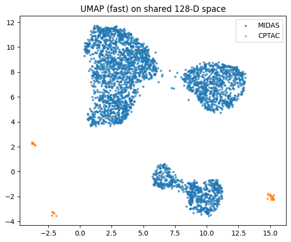

```python
# Put these BEFORE heavy imports to limit BLAS threads (optional but helps on Mac)

os.environ.setdefault("OMP_NUM_THREADS", "8")
os.environ.setdefault("OPENBLAS_NUM_THREADS", "8")


# Zp_128, Zr_128 assumed precomputed (MIDAS, CPTAC)
Zp = np.asarray(Zp_128, dtype=np.float32)
Zr = np.asarray(Zr_128, dtype=np.float32)

# ---- 1) fit on a small subset + all CPTAC, then transform full set ----
rng = np.random.default_rng(0)
fit_n = min(1500, Zp.shape[0])          # subset size for MIDAS
sel_p = rng.choice(Zp.shape[0], fit_n, replace=False)

Z_fit = np.vstack([Zp[sel_p], Zr])      # fit set
labels_fit = (["MIDAS"]*fit_n) + (["CPTAC"]*Zr.shape[0])

um_fast = umap.UMAP(
    n_components=2,
    n_neighbors=15,                     # down from 30
    min_dist=0.3,                       # a bit looser = less epochs needed
    n_epochs=100,                       # down from default ~200
    init="random",                      # faster than "spectral"
    metric="cosine",                    # better for normalized embeddings
    low_memory=True,
    force_approximation_algorithm=True, # NNDescent always
    random_state=0,
    verbose=True,
)

um_fast.fit(Z_fit)                      # quick fit on subset
U_p = um_fast.transform(Zp)             # fast transform for all MIDAS
U_r = um_fast.transform(Zr)             # fast transform for all CPTAC
U = np.vstack([U_p, U_r])

labels_all = np.array(["MIDAS"]*Zp.shape[0] + ["CPTAC"]*Zr.shape[0])

# ---- 2) plot ----
plt.figure(figsize=(6,5))
for name, c in [("MIDAS","tab:blue"), ("CPTAC","tab:orange")]:
    m = (labels_all == name)
    plt.scatter(U[m,0], U[m,1], s=6, alpha=0.6, label=name)
plt.legend(); plt.title("UMAP (fast) on shared 128-D space"); plt.tight_layout(); plt.show()
```

## Evaluation: Cross-repo KNN retrieval + simple classifier

**Goal**  
1) Retrieve nearest CPTAC radiology series for MIDAS derm photos in a shared 128-D space;  
2) Train a simple MIDAS-only classifier and score CPTAC to see modality/body-part patterns.

### Prerequisites

Saved by earlier steps:

- `outputs/midas_clip_img_512.npy`, `outputs/midas_labels.npy`
- `data/tcia/CPTAC-CM_png/cptac_cm_png_manifest.json`
- `outputs/cptac_clip_mapped_512.npy` (from the 2048→512 ridge mapping)

### Load & sanity checks

- Read MIDAS manifest + CLIP (512-D) and labels, CPTAC JSON manifest, and CPTAC CLIP-mapped (512-D).
- Assert equal counts between embeddings and their manifests.
- L2-normalize both embeddings for stable cosine geometry.

### Shared PCA → 128-D

- Fit a single PCA (n=128) on the **stacked** 512-D features (`[MIDAS ; CPTAC]`) to make a shared space.
- Transform each domain → `Zp_128` (MIDAS) and `Zr_128` (CPTAC).
- Save both to `outputs/midas_128.npy` and `outputs/cptac_128.npy`.

### A) Cross-repo KNN retrieval (MIDAS → CPTAC)

- Build a `NearestNeighbors` index on CPTAC (`Zr_128`) with **cosine** distance.
- Sample up to 50 random MIDAS queries and retrieve **top-5** CPTAC neighbors.
- Emit a tidy CSV `outputs/knn_midas_to_cptac_top5.csv` with:
  - MIDAS image path + binary label,
  - matched CPTAC `series_uid`, modality/description/caption (if present),
  - cosine distances and ranks.
- (Optional) You can visually inspect a few query rows or render thumbnails later.

### B) Simple classifier: Train on MIDAS → Score CPTAC

1. **5-fold AUROC on MIDAS**
   - `LogisticRegression` (`lbfgs`, `class_weight='balanced'`, `max_iter=1000`), stratified 5-fold.
   - Report mean AUROC and per-fold scores.
2. **Fit on full MIDAS**
   - Train LR on all `Zp_128` and labels `y`.
3. **Score CPTAC**
   - Predict melanoma probability on `Zr_128`; attach to CPTAC dataframe as `pred_score`.
   - Save to `outputs/cptac_scored_by_midas_lr.csv`.
4. **Quick plots & table**
   - Plot score distributions by **modality** (density histograms).
   - Show a small **top-K** table of highest-scoring CPTAC series for qualitative review.

### Outputs

- `outputs/midas_128.npy`, `outputs/cptac_128.npy`
- `outputs/knn_midas_to_cptac_top5.csv`
- `outputs/cptac_scored_by_midas_lr.csv`
- Console printouts: shapes, AUROC summary; histogram figure; top-K table display.

### Notes & Tips

- Cosine distance assumes L2-normalized rows—this cell normalizes defensively.
- For reproducibility, a fixed `SEED=0` is used in PCA and random sampling.
- You can tune `n_neighbors`, the number of sampled queries, and LR hyperparams to balance speed vs. fidelity.

```
Shapes → Zp_128: (3328, 128) Zr_128: (30, 128)
↪ Saved retrieval table → outputs/knn_midas_to_cptac_top5.csv
```

|  | midas_image | midas_label | cptac_series_uid | cptac_modality | cptac_desc | cptac_caption | distance_cosine | rank |
| --- | --- | --- | --- | --- | --- | --- | --- | --- |
| 0 | /Users/fanwang/Downloads/data/MRA-MIDAS/s-prd-... | 0 | 1.3.6.1.4.1.14519.5.2.1.3320.3273.669438171774... | PT | PET WB | melanoma patient \| modality: PT \| body part: W... | 0.983808 | 1 |
| 1 | /Users/fanwang/Downloads/data/MRA-MIDAS/s-prd-... | 0 | 1.3.6.1.4.1.14519.5.2.1.3320.3273.583237392388... | PT | PET WB | melanoma patient \| modality: PT \| body part: W... | 0.983932 | 2 |
| 2 | /Users/fanwang/Downloads/data/MRA-MIDAS/s-prd-... | 0 | 1.3.6.1.4.1.14519.5.2.1.3320.3273.229681506089... | PT | PET WB | melanoma patient \| modality: PT \| body part: W... | 0.984411 | 3 |
| 3 | /Users/fanwang/Downloads/data/MRA-MIDAS/s-prd-... | 0 | 1.3.6.1.4.1.14519.5.2.1.2932.1975.187028813452... | CT | 2.0 | melanoma patient \| modality: CT \| body part: C... | 0.984489 | 4 |
| 4 | /Users/fanwang/Downloads/data/MRA-MIDAS/s-prd-... | 0 | 1.3.6.1.4.1.14519.5.2.1.3320.3273.837949620161... | PT | PET WB 400 | melanoma patient \| modality: PT \| body part: W... | 0.984495 | 5 |
| 5 | /Users/fanwang/Downloads/data/MRA-MIDAS/s-prd-... | 0 | 1.3.6.1.4.1.14519.5.2.1.3320.3273.107577632221... | PT | PET Statistics | melanoma patient \| modality: PT \| body part: W... | 0.945571 | 1 |
| 6 | /Users/fanwang/Downloads/data/MRA-MIDAS/s-prd-... | 0 | 1.3.6.1.4.1.14519.5.2.1.3320.3273.486914768716... | PT | PET Statistics | melanoma patient \| modality: PT \| body part: W... | 0.945571 | 2 |
| 7 | /Users/fanwang/Downloads/data/MRA-MIDAS/s-prd-... | 0 | 1.3.6.1.4.1.14519.5.2.1.3320.3273.229681506089... | PT | PET WB | melanoma patient \| modality: PT \| body part: W... | 0.953619 | 3 |
| 8 | /Users/fanwang/Downloads/data/MRA-MIDAS/s-prd-... | 0 | 1.3.6.1.4.1.14519.5.2.1.3320.3273.669438171774... | PT | PET WB | melanoma patient \| modality: PT \| body part: W... | 0.953941 | 4 |
| 9 | /Users/fanwang/Downloads/data/MRA-MIDAS/s-prd-... | 0 | 1.3.6.1.4.1.14519.5.2.1.3320.3273.583237392388... | PT | PET WB | melanoma patient \| modality: PT \| body part: W... | 0.955153 | 5 |

```
MIDAS 5-fold AUROC (mean): 0.686 | folds: [0.64  0.702 0.748 0.661 0.679]
↪ Saved CPTAC scores → outputs/cptac_scored_by_midas_lr.csv
```

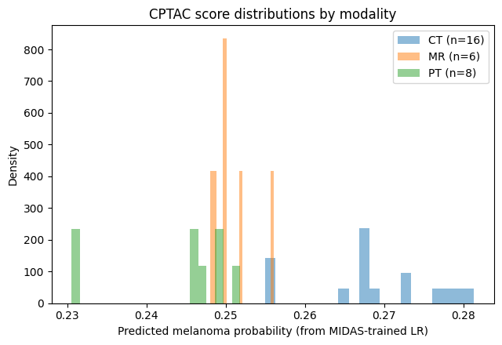

|  | series_uid | modality | body_part | series_desc | pred_score |
| --- | --- | --- | --- | --- | --- |
| 16 | 1.3.6.1.4.1.14519.5.2.1.3320.3273.130945050277... | CT | ABDOMEN | Arterial Phase 1.5 I30f | 0.281336 |
| 24 | 1.3.6.1.4.1.14519.5.2.1.3320.3273.380341936539... | CT | ABDOMEN | Arterial Phase 5.0 B30f | 0.279904 |
| 9 | 1.3.6.1.4.1.14519.5.2.1.2932.1975.126887613559... | CT |  | CONTRAST | 0.277447 |
| 25 | 1.3.6.1.4.1.14519.5.2.1.3320.3273.398961036320... | CT | ABDOMEN | CT WB 3.0 B70f | 0.276741 |
| 6 | 1.3.6.1.4.1.14519.5.2.1.2857.3159.311502209643... | CT | ABDOMEN | CAP ST 5X5, iDose (3) | 0.272579 |
| 7 | 1.3.6.1.4.1.14519.5.2.1.2857.3159.314497506012... | CT | ABDOMEN | AP LIVER, iDose (3) | 0.272578 |
| 14 | 1.3.6.1.4.1.14519.5.2.1.2932.1975.697806084527... | CT | CHEST_TO_PELVIS | 4.0 | 0.268679 |
| 8 | 1.3.6.1.4.1.14519.5.2.1.2932.1975.112089715947... | CT | CHEST_TO_PELVIS | 4.0 | 0.267694 |
| 10 | 1.3.6.1.4.1.14519.5.2.1.2932.1975.153876355376... | CT | CHEST_TO_PELVIS | 4.0 | 0.267372 |
| 18 | 1.3.6.1.4.1.14519.5.2.1.3320.3273.192361203560... | CT | ABDOMEN | CT WB 3.0 B30f | 0.267202 |
| 23 | 1.3.6.1.4.1.14519.5.2.1.3320.3273.313382569712... | CT | ABDOMEN | CT WB 3.0 B30f | 0.267181 |
| 22 | 1.3.6.1.4.1.14519.5.2.1.3320.3273.265219228892... | CT | ABDOMEN | CT WB 3.0 B30f | 0.267030 |
| 21 | 1.3.6.1.4.1.14519.5.2.1.3320.3273.252548573746... | CT | ABDOMEN | CT WB 3.0 B30f | 0.265285 |
| 12 | 1.3.6.1.4.1.14519.5.2.1.2932.1975.187028813452... | CT | CHEST_TO_PELVIS | 2.0 | 0.256249 |
| 3 | 1.3.6.1.4.1.14519.5.2.1.2857.3159.238004317838... | MR |  | SAG T1 SE+C | 0.256059 |

```python
# === Evaluation: KNN retrieval + simple classifier ===
# Prereqs saved by earlier steps:
#   outputs/midas_clip_img_512.npy, outputs/midas_labels.npy
#   data/tcia/CPTAC-CM_png/cptac_cm_png_manifest.json
#   (optional) outputs/cptac_clip_mapped_512.npy
#
# If you don't have cptac_clip_mapped_512.npy yet, make sure you ran the ridge-mapping step.

# -------- paths --------
OUT         = Path("./outputs"); OUT.mkdir(exist_ok=True)
MIDAS_CSV   = Path("./outputs/midas_manifest.csv")
MIDAS_EMB   = Path("./outputs/midas_clip_img_512.npy")
MIDAS_Y     = Path("./outputs/midas_labels.npy")
CPTAC_JSON  = Path("./data/tcia/CPTAC-CM_png/cptac_cm_png_manifest.json")
CPTAC_EMB   = Path("./outputs/cptac_clip_mapped_512.npy")  # from ridge map (2048->512)
SEED        = 0

# -------- load data --------
midas_df = pd.read_csv(MIDAS_CSV)
Zp_512   = np.load(MIDAS_EMB)         # (N_midas, 512)
y        = np.load(MIDAS_Y)           # (N_midas,)
cptac    = pd.read_json(CPTAC_JSON)   # columns: series_uid, modality, body_part, series_desc, pngs, caption
Zr_512   = np.load(CPTAC_EMB)         # (N_cptac, 512)

# safety checks
assert Zp_512.shape[0] == len(midas_df), "Mismatch MIDAS embeddings vs manifest"
assert Zr_512.shape[0] == len(cptac), "Mismatch CPTAC embeddings vs manifest"

# L2 normalize (should already be, but safe)
Zp_512 = Zp_512 / (np.linalg.norm(Zp_512, axis=1, keepdims=True)+1e-9)
Zr_512 = Zr_512 / (np.linalg.norm(Zr_512, axis=1, keepdims=True)+1e-9)

# -------- Shared PCA to 128-D (as in plan) --------
np.random.seed(SEED)
pca = PCA(n_components=128, random_state=SEED)
Z_all_512 = np.vstack([Zp_512, Zr_512])
pca.fit(Z_all_512)

Zp_128 = pca.transform(Zp_512).astype(np.float32)
Zr_128 = pca.transform(Zr_512).astype(np.float32)

np.save(OUT/"midas_128.npy", Zp_128)
np.save(OUT/"cptac_128.npy", Zr_128)

print("Shapes →", "Zp_128:", Zp_128.shape, "Zr_128:", Zr_128.shape)

# =========================================================
# A) Cross-repo KNN retrieval (MIDAS -> CPTAC)
# =========================================================
# Use cosine distance in 128-D
knn = NearestNeighbors(
    n_neighbors=5, metric="cosine", algorithm="auto", n_jobs=-1
).fit(Zr_128)

# pick a small random sample of MIDAS queries for display (adjust as you like)
rng = np.random.default_rng(SEED)
q_idx = rng.choice(Zp_128.shape[0], size=min(50, Zp_128.shape[0]), replace=False)

dist, idx = knn.kneighbors(Zp_128[q_idx])
# Build a tidy table with MIDAS query → top-5 CPTAC matches
rows = []
for qi, (drow, irow) in enumerate(zip(dist, idx)):
    mrow = midas_df.iloc[q_idx[qi]]
    for rank, (dj, ij) in enumerate(zip(drow, irow), start=1):
        crow = cptac.iloc[ij]
        rows.append({
            "midas_image": mrow["image_path"],
            "midas_label": int(mrow["diagnosis_bin"]),
            "cptac_series_uid": crow["series_uid"],
            "cptac_modality": crow.get("modality", ""),
            "cptac_desc": crow.get("series_desc", ""),
            "cptac_caption": crow.get("caption", ""),
            "distance_cosine": float(dj),
            "rank": rank
        })

retrieval_df = pd.DataFrame(rows)
retrieval_csv = OUT/"knn_midas_to_cptac_top5.csv"
retrieval_df.to_csv(retrieval_csv, index=False)
print("↪ Saved retrieval table →", retrieval_csv)
display(retrieval_df.head(10))

# (Optional) quick qualitative peek: show a few MIDAS thumbnails and list top matches
# Note: rendering lots of images in Jupyter can be slow; we keep this textual by default.


# =========================================================
# B) Simple classifier trained on MIDAS → score CPTAC
# =========================================================
# 1) Cross-validated AUROC on MIDAS, then 2) fit on full MIDAS, 3) score CPTAC and plot by modality.

def cv_auroc_lr(X, y, seed=SEED):
    skf = StratifiedKFold(n_splits=5, shuffle=True, random_state=seed)
    aucs = []
    for tr, te in skf.split(X, y):
        clf = LogisticRegression(
            max_iter=1000,
            class_weight="balanced",
            solver="lbfgs",
            n_jobs=-1
        )
        clf.fit(X[tr], y[tr])
        p = clf.predict_proba(X[te])[:, 1]
        aucs.append(roc_auc_score(y[te], p))
    return float(np.mean(aucs)), [float(a) for a in aucs]

mid_auc, fold_aucs = cv_auroc_lr(Zp_128, y)
print(f"MIDAS 5-fold AUROC (mean): {mid_auc:.3f} | folds:", np.round(fold_aucs, 3))

# Fit on all MIDAS
clf_full = LogisticRegression(
    max_iter=1000, class_weight="balanced", solver="lbfgs", n_jobs=-1
).fit(Zp_128, y)

# Score CPTAC
cptac_scores = clf_full.predict_proba(Zr_128)[:, 1]
cptac_scored = cptac.copy()
cptac_scored["pred_score"] = cptac_scores

# Save scored table
scored_csv = OUT/"cptac_scored_by_midas_lr.csv"
cptac_scored.to_csv(scored_csv, index=False)
print("↪ Saved CPTAC scores →", scored_csv)

# Plot score distributions by modality (quick look)
plt.figure(figsize=(6.5, 4.5))
for mod in sorted(cptac_scored["modality"].fillna("NA").unique()):
    m = (cptac_scored["modality"].fillna("NA") == mod)
    if m.sum() == 0:
        continue
    plt.hist(cptac_scored.loc[m, "pred_score"], bins=20, alpha=0.5, label=f"{mod} (n={m.sum()})", density=True)
plt.xlabel("Predicted melanoma probability (from MIDAS-trained LR)")
plt.ylabel("Density")
plt.title("CPTAC score distributions by modality")
plt.legend()
plt.tight_layout()
plt.show()

# Also dump a small top-K table for quick inspection
topk = cptac_scored.sort_values("pred_score", ascending=False).head(15)
display(topk[["series_uid","modality","body_part","series_desc","pred_score"]])
```

## Qualitative retrieval panels: MIDAS query vs. top-K CPTAC matches

**Purpose**  
Visually inspect cross-repository retrieval quality by showing one **MIDAS** derm photo (query) on the left and its **top-K CPTAC** radiology matches on the right, using the precomputed KNN results.

**Inputs**

- `./outputs/midas_manifest.csv` — MIDAS images + labels.
- `./data/tcia/CPTAC-CM_png/cptac_cm_png_manifest.json` — CPTAC series with PNG thumbnails and captions.
- `./outputs/knn_midas_to_cptac_top5.csv` — KNN table with `midas_image`, `midas_label`, `cptac_series_uid`, `cptac_modality`, `series_desc`, `distance_cosine`, `rank`.

**Key function: `show_panel(query_row, k=5, figsize=(12,3.2))`**

**Workflow**

1. Load the three data sources (MIDAS CSV, CPTAC JSON, KNN CSV).
2. Filter the KNN table to `rank==1` to get one entry per MIDAS query.
3. For a few random queries, call `show_panel(row, k=5)` to visualize the query and its top-5 matches.
4. Use `plt.show()` to display each panel inline.

**What to look for**

- Are high-scoring matches (small cosine **distance**) semantically reasonable given the MIDAS query?
- Any modality/body-part patterns in the retrieved CPTAC series?
- Outliers with unexpectedly large distances or missing thumbnails.

**Notes**

- The function uses only the **first** PNG per CPTAC series for speed; extend to multiple slices if desired.
- Ensure the `pngs` paths exist on disk; otherwise, a panel cell will render blank.
- You can sort or filter `retr` by `distance_cosine` or `modality` to target specific cases.

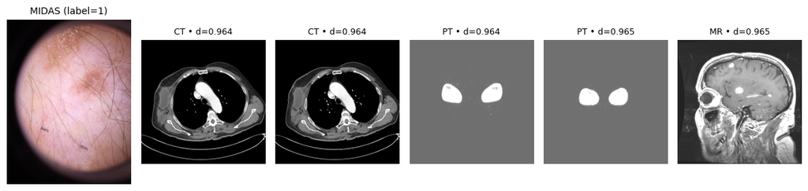

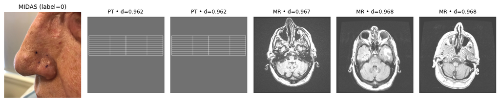

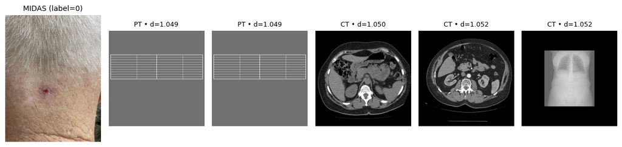

```python
OUT         = Path("./outputs")
MIDAS_CSV   = OUT/"midas_manifest.csv"
CPTAC_JSON  = Path("./data/tcia/CPTAC-CM_png/cptac_cm_png_manifest.json")
RETR_CSV    = OUT/"knn_midas_to_cptac_top5.csv"

midas_df = pd.read_csv(MIDAS_CSV)
cptac    = pd.read_json(CPTAC_JSON)
retr     = pd.read_csv(RETR_CSV)

def show_panel(query_row, k=5, figsize=(12,3.2)):
    """
    query_row: a single row from retrieval_df (rank==1 recommended to pick the MIDAS image);
               we'll collect its top-k rows by midas_image.
    """
    qimg = query_row["midas_image"]
    subset = retr[retr["midas_image"]==qimg].sort_values("rank").head(k)
    # build figure: 1 row, k+1 columns (left = MIDAS, right = k CPTAC)
    fig, axes = plt.subplots(1, k+1, figsize=figsize)
    # MIDAS query
    im = Image.open(qimg).convert("RGB")
    axes[0].imshow(im); axes[0].set_title(f"MIDAS (label={query_row['midas_label']})", fontsize=10)
    axes[0].axis("off")
    # CPTAC matches
    for j, (_, r) in enumerate(subset.iterrows(), start=1):
        # first PNG for that CPTAC series
        srow = cptac[cptac["series_uid"]==r["cptac_series_uid"]].iloc[0]
        pngs = srow["pngs"]
        pth  = pngs[0] if isinstance(pngs, list) and len(pngs) else None
        if pth and Path(pth).exists():
            im = Image.open(pth).convert("RGB")
            axes[j].imshow(im)
        axes[j].set_title(f"{r['cptac_modality']} • d={r['distance_cosine']:.3f}", fontsize=9)
        axes[j].set_xlabel(srow.get("series_desc","")[:22], fontsize=8)
        axes[j].axis("off")
    plt.tight_layout()
    return fig

# demo a few random queries
cand = retr[retr["rank"]==1].copy()
for _ in range(3):  # show 3 panels
    row = cand.sample(1, random_state=np.random.randint(0, 99999)).iloc[0]
    show_panel(row, k=5)
    plt.show()
```

## Quick sanity check: Top-1 retrieval distance summary

**Goal**  
Summarize the cosine **distance** of the **top-1** CPTAC neighbor for each MIDAS query from the KNN results. Lower distance ⇒ closer match.

**Inputs**

- `./outputs/knn_midas_to_cptac_top5.csv` — table with columns like `rank` and `distance_cosine`.

**What the cell does**

1. Loads the KNN table into a DataFrame.
2. Filters to `rank == 1` (the nearest neighbor per query).
3. Prints the **median**, **minimum**, and **maximum** cosine distances across all top-1 matches.

**How to read it**

- Distances range from 0 (identical direction) to 2 for cosine *distance* if defined as `1 - cosine_similarity` (common range is 0–2; many pipelines stay in 0–1).
- **Smaller** values indicate **better** alignment between the MIDAS image embedding and its best CPTAC match.

**Notes**

- If you observe large medians (e.g., > ~0.8 with cosine distance), consider improving the shared embedding space (e.g., better text prompts, different mapping, or normalization).
- You can also compare this summary against a **random baseline** to verify that retrieval is better than chance.

```python
knn = pd.read_csv("./outputs/knn_midas_to_cptac_top5.csv")

# safest: bracket access
top1 = knn[knn['rank'] == 1]

print("Top-1 distance (median/min/max):",
      top1['distance_cosine'].median(),
      top1['distance_cosine'].min(),
      top1['distance_cosine'].max())
```

```
Top-1 distance (median/min/max): 1.0183409452438354 0.9043991565704346 1.173896551132202
```

### Alias saved embeddings to standard filenames

**Purpose:**  
Copy (save) the previously computed shared-space embeddings to the expected filenames used by later steps.

**Inputs:**

- `outputs/midas_128.npy` — MIDAS (photo) embeddings in 128-D
- `outputs/cptac_128.npy` — CPTAC (radiology) embeddings in 128-D

**Actions:**

- Save MIDAS as `outputs/Z_photo_128.npy`
- Save CPTAC as `outputs/Z_rad_128.npy`

**Output/Log:**  
Prints the aliased filenames and their shapes to confirm success.

```python
OUT = Path("./outputs")

Zp_128 = np.load(OUT/"midas_128.npy")
Zr_128 = np.load(OUT/"cptac_128.npy")

np.save(OUT/"Z_photo_128.npy", Zp_128)
np.save(OUT/"Z_rad_128.npy",   Zr_128)

print("Aliased to expected names:",
      (OUT/"Z_photo_128.npy").name, Zp_128.shape, "|",
      (OUT/"Z_rad_128.npy").name,   Zr_128.shape)
```

```
Aliased to expected names: Z_photo_128.npy (3328, 128) | Z_rad_128.npy (30, 128)
```

### Train & evaluate a simple classifier on MIDAS (128-D)

**Goal**  
Evaluate how well the 128-D MIDAS embeddings (`Z_photo_128.npy`) separate melanoma vs non-melanoma, using a lightweight logistic-regression baseline.

**Inputs**

- `outputs/Z_photo_128.npy` → MIDAS embeddings of shape *(N_photo, 128)*
- `outputs/midas_labels.npy` → binary labels *(N_photo,)*

**Procedure**

1. Report dataset shapes and positive rate for a quick sanity check.
2. Perform **5-fold Stratified CV** with `LogisticRegression` (LBFGS, `max_iter=500`) and compute **AUROC** per fold.
3. Print mean ± std AUROC and per-fold scores.
4. Fit the final classifier on **all** MIDAS data.
5. Persist the trained model to `outputs/midas_logreg_128.joblib` (via `joblib.dump`) for reuse.

**Notes**

- Stratification preserves label balance across folds.
- AUROC is threshold-free and robust for imbalanced datasets; consider tracking **PR-AUC** too if positives are rare.
- Set a `random_state` on the final model if you need full reproducibility.

```python
OUT = Path("./outputs")

# Load features + labels
Zp = np.load(OUT/"Z_photo_128.npy")         # (N_photo, 128)
y  = np.load(OUT/"midas_labels.npy")        # (N_photo,), 0/1

print("MIDAS shape:", Zp.shape, "labels:", y.shape, "pos_rate:", y.mean().round(3))

# 5-fold stratified CV AUROC
cv = StratifiedKFold(n_splits=5, shuffle=True, random_state=42)
aucs = []
for tr, te in cv.split(Zp, y):
    clf = LogisticRegression(max_iter=500, solver="lbfgs")
    clf.fit(Zp[tr], y[tr])
    p = clf.predict_proba(Zp[te])[:,1]
    aucs.append(roc_auc_score(y[te], p))
print("MIDAS AUROC (5-fold): mean=%.3f  std=%.3f  folds=%s" % (np.mean(aucs), np.std(aucs), [round(a,3) for a in aucs]))

# Fit final model on all MIDAS
clf = LogisticRegression(max_iter=500, solver="lbfgs").fit(Zp, y)
# Save for later use (optional)
joblib.dump(clf, OUT/"midas_logreg_128.joblib")
print("Saved classifier →", OUT/"midas_logreg_128.joblib")
```

```
MIDAS shape: (3328, 128) labels: (3328,) pos_rate: 0.197
MIDAS AUROC (5-fold): mean=0.680  std=0.005  folds=[0.687, 0.676, 0.673, 0.684, 0.681]
Saved classifier → outputs/midas_logreg_128.joblib
```

### Score CPTAC series with a MIDAS-trained classifier & visualize distributions

**Objective**  
Use the logistic-regression model trained on MIDAS 128-D embeddings to score CPTAC radiology series for “melanoma-likeness,” then visualize score distributions overall, by modality, and by body part.

**Inputs**

- `outputs/Z_rad_128.npy` — CPTAC embeddings, shape *(N_series, 128)*
- `outputs/midas_logreg_128.joblib` — logistic regression trained on MIDAS
- `data/tcia/CPTAC-CM_png/cptac_cm_png_manifest.json` — CPTAC metadata (series_uid, modality, body_part, etc.)

**Outputs**

- `outputs/cptac_scored.csv` — table of CPTAC series with predicted score column `score`.
- Three quick-look plots: overall score histogram, by-modality density histograms, and by-body-part density histograms.

**Notes**

- The assertion ensures the metadata list and embedding matrix have the same number of rows (guarding against ordering/filtering mismatches).
- Histograms use `density=True` for per-group comparison; adjust bins or alpha as needed.
- Scores are not calibrated probabilities unless you performed calibration earlier; interpret them as relative “melanoma-likeness.”

```
Saved CPTAC scores → outputs/cptac_scored.csv
```

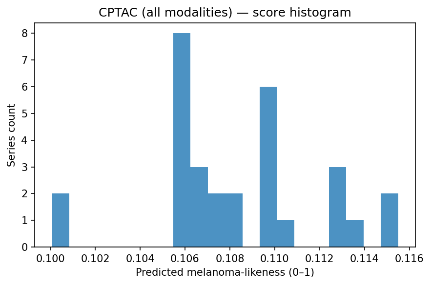

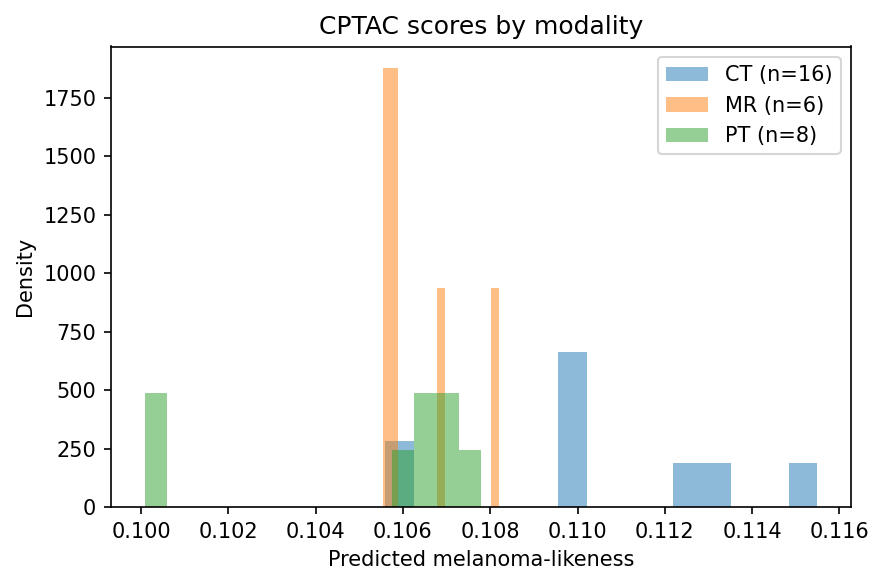

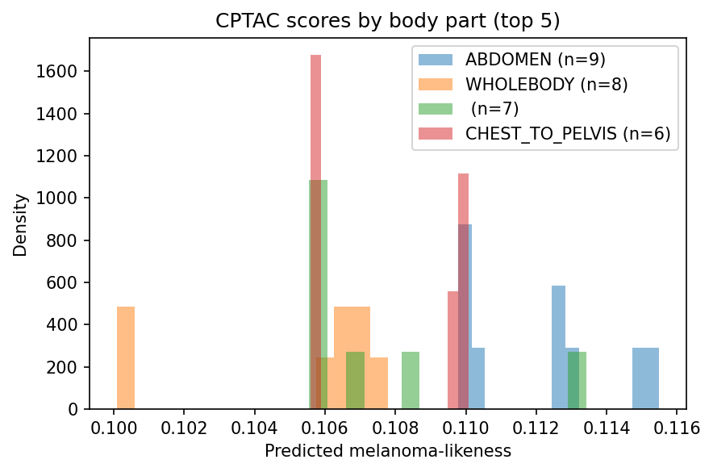

```python
plt.rcParams['figure.dpi'] = 150


OUT = Path("./outputs")
Zr  = np.load(OUT/"Z_rad_128.npy")   # (N_series, 128)

# Load the same classifier we just trained
clf = joblib.load(OUT/"midas_logreg_128.joblib")

# Predict “melanoma-likeness” on CPTAC
scores = clf.predict_proba(Zr)[:,1]

# Bring CPTAC metadata (from earlier PNG manifest JSON)
MAN = Path("./data/tcia/CPTAC-CM_png/cptac_cm_png_manifest.json")
cptac = pd.read_json(MAN)
assert len(cptac) == len(scores), f"Metadata rows {len(cptac)} != Z_rad rows {len(scores)}"

cptac_scored = cptac.assign(score=scores)
cptac_scored.to_csv(OUT/"cptac_scored.csv", index=False)
print("Saved CPTAC scores →", OUT/"cptac_scored.csv")

# --- Quick plots ---
plt.figure(figsize=(6,4))
plt.hist(cptac_scored["score"], bins=20, alpha=0.8)
plt.xlabel("Predicted melanoma-likeness (0–1)")
plt.ylabel("Series count")
plt.title("CPTAC (all modalities) — score histogram")
plt.tight_layout()
plt.show()

# By modality
plt.figure(figsize=(6,4))
for m in sorted(cptac_scored["modality"].fillna("UNK").unique()):
    vals = cptac_scored[cptac_scored["modality"].fillna("UNK")==m]["score"].to_numpy()
    if len(vals)==0: continue
    plt.hist(vals, bins=15, alpha=0.5, label=f"{m} (n={len(vals)})", density=True)
plt.xlabel("Predicted melanoma-likeness")
plt.ylabel("Density")
plt.title("CPTAC scores by modality")
plt.legend()
plt.tight_layout()
plt.show()

# By body part (top 5 most common; fill blanks as 'UNK')
bp_counts = cptac_scored["body_part"].fillna("UNK").value_counts()
tops = bp_counts.index[:5].tolist()
plt.figure(figsize=(6,4))
for bp in tops:
    vals = cptac_scored[cptac_scored["body_part"].fillna("UNK")==bp]["score"].to_numpy()
    if len(vals)==0: continue
    plt.hist(vals, bins=15, alpha=0.5, label=f"{bp} (n={len(vals)})", density=True)
plt.xlabel("Predicted melanoma-likeness")
plt.ylabel("Density")
plt.title("CPTAC scores by body part (top 5)")
plt.legend()
plt.tight_layout()
plt.show()
```

### Fast top-5 retrieval via cosine similarity (vectorized)

**What it does**  
Computes **top-5 CPTAC matches for each MIDAS image** using cosine similarity in the shared 128-D space.

**Steps**

1. **L2-normalize** both matrices so dot products equal cosine similarity.
2. Compute the full **similarity matrix** `S = Z_photo · Z_rad^T`.
3. Use `argpartition` to get **top-k indices** per row, then sort those k by exact similarity.
4. Build a tidy table with `photo_idx`, `series_idx`, `rank`, `sim`, and `distance_cosine = 1 − sim`.

**Inputs**

- `outputs/Z_photo_128.npy` (N_photo × 128)
- `outputs/Z_rad_128.npy` (N_series × 128)

**Output**

- `outputs/knn_midas_to_cptac_top5.csv` — top-5 nearest CPTAC series per MIDAS image.

```python
# Fast cosine top-5 using matrix multiply on L2-normalized rows
def l2n(a, eps=1e-9):
    n = np.linalg.norm(a, axis=1, keepdims=True); n[n<eps] = eps
    return a / n

Zp_n = l2n(np.load("./outputs/Z_photo_128.npy"))
Zr_n = l2n(np.load("./outputs/Z_rad_128.npy"))

S = Zp_n @ Zr_n.T                         # cosine similarity (N_photo x N_series)
topk = 5
idx = np.argpartition(-S, kth=topk-1, axis=1)[:,:topk]
# exact sort within the topk
rows = []
for i in range(S.shape[0]):
    pairs = sorted([(j, S[i,j]) for j in idx[i]], key=lambda x: -x[1])
    for rank,(j,sim) in enumerate(pairs, start=1):
        rows.append({"photo_idx": i, "series_idx": j, "rank": rank, "sim": float(sim), "distance_cosine": float(1.0-sim)})
knn = pd.DataFrame(rows)
knn.to_csv("./outputs/knn_midas_to_cptac_top5.csv", index=False)
print("Saved → ./outputs/knn_midas_to_cptac_top5.csv")
```

```
Saved → ./outputs/knn_midas_to_cptac_top5.csv
```

### Summarize CPTAC scores by modality and body part

**Goal**  
Compute descriptive statistics of the CPTAC “melanoma-likeness” scores, grouped by modality and by body part.

**What the code does**

- Loads `./outputs/cptac_scored.csv` (must contain: `series_uid`, `modality`, `body_part`, `score`).
- For each group:
  - Calculates **median** and **IQR** (`p25`, `p75`).
  - Estimates a **95% bootstrap CI** for the median (5,000 resamples, fixed RNG for reproducibility).
- Prints two tables: 1) Summary **by modality**  
  2) Summary **by body part** (top 8 rows by median)

**Why bootstrap?**  
The sampling distribution of the median can be non-normal; bootstrap gives a simple, assumption-light CI.

**Output**  
Two neatly sorted DataFrames with columns:  
`[group, n, median, p25, p75, ci2.5, ci97.5]`.

```python
scores = pd.read_csv("./outputs/cptac_scored.csv")  # columns: series_uid, modality, body_part, score
def summary(df, by):
    out = []
    for name, g in df.groupby(by):
        s = g["score"].to_numpy()
        m = np.median(s); lo, hi = np.percentile(s, [25, 75])
        # bootstrap 95% CI for median
        bs = np.median(np.random.default_rng(0).choice(s, (5000, len(s)), replace=True), axis=1)
        ci = np.percentile(bs, [2.5, 97.5])
        out.append((name, len(s), m, lo, hi, ci[0], ci[1]))
    return pd.DataFrame(out, columns=[by, "n", "median", "p25", "p75", "ci2.5", "ci97.5"]).sort_values("median", ascending=False)

print("By modality:\n", summary(scores, "modality"), "\n")
print("By body_part (top 8):\n", summary(scores, "body_part").head(8))
```

```
By modality:
   modality   n    median       p25       p75     ci2.5    ci97.5
0       CT  16  0.110065  0.109759  0.112721  0.109780  0.112586
2       PT   8  0.106602  0.104649  0.107161  0.100081  0.107168
1       MR   6  0.105834  0.105655  0.106567  0.105571  0.107499

By body_part (top 8):
          body_part  n    median       p25       p75     ci2.5    ci97.5
0          ABDOMEN  9  0.112586  0.110058  0.113126  0.109954  0.115023
1  CHEST_TO_PELVIS  6  0.107792  0.105674  0.109962  0.105600  0.110061
2        WHOLEBODY  8  0.106602  0.104649  0.107161  0.100081  0.107168
```

### CPTAC PNG browser with smarter titles & compact grid

**Goal**  
Browse CPTAC series as small PNG panels with informative, compact row titles, using the score table plus the PNG manifest.

**Inputs**

- `data/tcia/CPTAC-CM_png/cptac_cm_png_manifest.json` → per‐series metadata and PNG paths.
- `outputs/cptac_scores.csv` → per‐series scores (fallback if `scores` not already in memory).

**Key steps**

1. **Normalize metadata**
   - Fill missing `body_part` by scanning `series_desc` for common tags (e.g., *BRAIN*, *CHEST_TO_PELVIS*, *WHOLEBODY*).
   - Ensure `pngs` is a list and filter to files that actually exist.
2. **Align scores with metadata**
   - Load `scores` (from memory or CSV).
   - If `modality` / `body_part` are missing in `scores`, merge from the manifest.
   - Build lookup maps: `score_map`, `mod_map`, `body_map`.
3. **Utility helpers**
   - `uid_tail(uid)`: short UID suffix for compact titles.
   - `get_pngs(uid)`: fetch PNG list for a series.
4. **Compact grid renderer**
   - `show(series_ids, title, max_cols=5)`:
     - Truncates each row to ≤ `max_cols` images.
     - Auto‐determines `ncols` to **avoid blank columns**.
     - First tile in each row gets a compact 2‐line title:  
       `"{modality} • {score:.3f}\n{body_part} • …{uid_tail}"`.
5. **What gets displayed**
   - **Top 5** series by score.
   - **Bottom 5** series by score.
   - *(Optional)* **Top per modality** by within‐modality z‐score.

**Output**

- Three matplotlib figures (top, bottom, and optional per‐modality winners), each a compact grid of PNGs with readable titles.

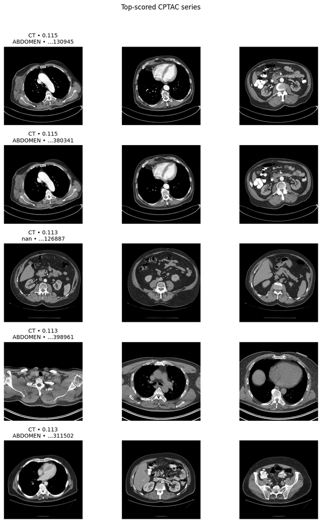

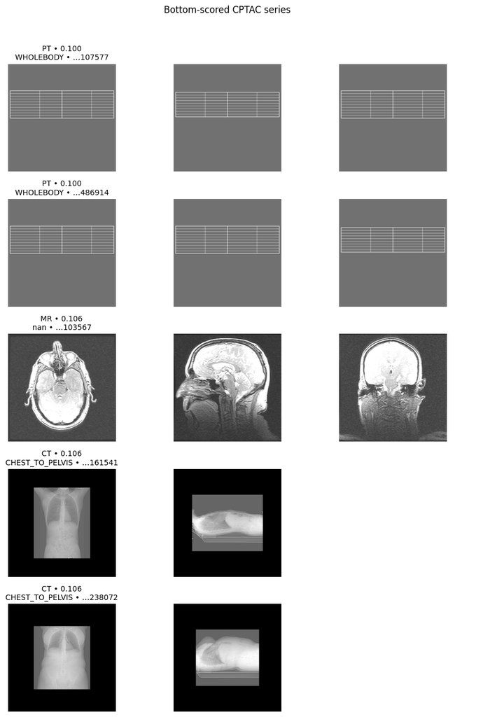

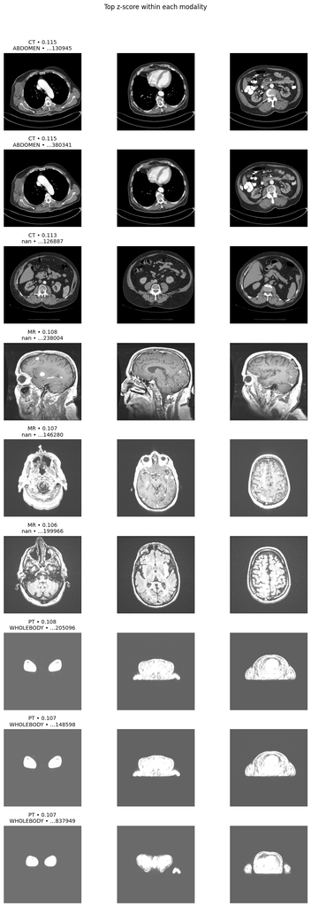

```python
# --- CPTAC PNG browser with smarter titles & compact grid --------------------

# --- inputs (re-use your existing DataFrames if already in memory) ---
MAN_PATH    = "./data/tcia/CPTAC-CM_png/cptac_cm_png_manifest.json"
SCORES_PATH = "./outputs/cptac_scores.csv"   # fallback if `scores` not in memory

man = pd.read_json(MAN_PATH)

# 1) Fill missing body_part from series/study description (nice for MR)
def infer_body_part_row(row):
    bp = (row.get("body_part") or "").strip()
    if bp:
        return bp
    sdesc = (row.get("series_desc") or "").upper()
    # try common tags
    tags = [
        "BRAIN","HEAD","NECK","CHEST","ABDOMEN","PELVIS",
        "CHEST_TO_PELVIS","CHEST TO PELVIS","WHOLEBODY","WHOLE BODY","WB"
    ]
    for t in tags:
        if t in sdesc:
            return t.replace(" ","_")
    return "UNK"

if "body_part" not in man.columns:
    man["body_part"] = "UNK"
man["body_part"] = man.apply(infer_body_part_row, axis=1)

# ensure png list column is always a list (and filtered to existing files)
def normalize_pngs(xs):
    xs = xs if isinstance(xs, (list, tuple)) else []
    return [p for p in xs if isinstance(p, str) and os.path.exists(p)]
man["pngs"] = man["pngs"].apply(normalize_pngs)

# load/align scores
try:
    scores  # if already in memory, leave it
except NameError:
    scores = pd.read_csv(SCORES_PATH)

# if modality/body_part missing in scores, merge them from manifest
if not {"modality","body_part"}.issubset(scores.columns):
    scores = scores.merge(
        man[["series_uid","modality","body_part"]],
        on="series_uid", how="left"
    )

# convenience lookups
score_map = dict(zip(scores.series_uid, scores.score))
mod_map   = dict(zip(scores.series_uid, scores.modality))
body_map  = dict(zip(scores.series_uid, scores.body_part))

def uid_tail(uid, n=6):
    return uid.split(".")[-1][:n]

def get_pngs(uid):
    r = man.loc[man.series_uid == uid]
    if r.empty:
        return []
    return r.iloc[0]["pngs"]

def show(series_ids, title, max_cols=5):
    """Compact grid (no blank columns), robust to rows with <max_cols PNGs."""
    # resolve & cap each row’s png list; compute actual number of columns
    png_lists, ncols = [], 0
    for uid in series_ids:
        pngs = get_pngs(uid)
        pngs = pngs[:max_cols] if isinstance(pngs, list) else []
        png_lists.append(pngs)
        ncols = max(ncols, len(pngs))
    if ncols == 0:
        print(f"[WARN] No PNGs found for: {series_ids}")
        return

    nrows = len(series_ids)
    fig, axes = plt.subplots(nrows, ncols, figsize=(3.2*ncols, 2.6*nrows))
    if nrows == 1 and ncols == 1:
        axes = np.array([[axes]])
    elif nrows == 1:
        axes = axes[None, :]
    elif ncols == 1:
        axes = axes[:, None]

    for i, uid in enumerate(series_ids):
        row_pngs = png_lists[i]
        for j in range(ncols):
            ax = axes[i, j]
            if j < len(row_pngs):
                img = plt.imread(row_pngs[j])
                ax.imshow(img, cmap="gray")
                ax.axis("off")
                if j == 0:
                    s   = score_map.get(uid, float("nan"))
                    mod = (mod_map.get(uid, "") or "?")
                    bp  = (body_map.get(uid, "") or "")
                    ax.set_title(f"{mod} • {s:.3f}\n{bp} • …{uid_tail(uid)}", fontsize=10)
            else:
                ax.axis("off")

    plt.suptitle(title, y=1.02, fontsize=12)
    plt.tight_layout()
    plt.show()

# --- choose the series to display (top/bottom by score) ---
top = scores.sort_values("score", ascending=False).head(5)["series_uid"].tolist()
bot = scores.sort_values("score", ascending=True ).head(5)["series_uid"].tolist()

show(top, "Top-scored CPTAC series",   max_cols=5)
show(bot, "Bottom-scored CPTAC series", max_cols=5)

# (Optional) show best-per-modality by z-score within modality
if "modality" in scores.columns:
    scores["z_in_mod"] = scores.groupby("modality")["score"].transform(
        lambda x: (x - x.mean()) / (x.std(ddof=1) + 1e-9)
    )
    top_by_mod = (
        scores.sort_values(["modality", "z_in_mod"], ascending=[True, False])
              .groupby("modality")
              .head(3)["series_uid"].tolist()
    )
    show(top_by_mod, "Top z-score within each modality", max_cols=5)
```

### Train → Calibrate → Apply: MIDAS → CPTAC melanoma scoring

**Purpose**  
1) Train and cross-validate a calibrated logistic-regression classifier on **MIDAS** CLIP-512 embeddings.  
2) Fit a final calibrated model on all MIDAS data.  
3) Apply it to **CPTAC** radiology embeddings (already mapped into CLIP-512) and summarize results.

#### 1) MIDAS classifier with calibrated probabilities

- **Data**:
  - `outputs/midas_clip_img_512.npy` → image embeddings `(N_photo, 512)`
  - `outputs/midas_labels.npy` → binary labels `(N_photo,)`
- **Modeling**:
  - Pipeline: `StandardScaler` → `LogisticRegression(C=1.0, lbfgs, class_weight='balanced', max_iter=2000)`.
  - **5-fold Stratified CV**: compute **AUROC** and **PR-AUC** on held-out folds.
  - **Probability calibration**: `CalibratedClassifierCV(..., method='sigmoid')` wraps the pipeline to correct probability scale; CV=3 within each training fold.
  - Report mean ± std for AUROC and PR-AUC; store out-of-fold probabilities for sanity checks.
- **Final model**:
  - Refit the same pipeline on **all** MIDAS data with **CV=5 calibration**.
  - Save to `outputs/midas_calibrated_lr.joblib`.

**Why calibration?**  
Logistic regression often produces well-behaved scores, but domain shift and regularization can still mis-scale probabilities. Platt (“sigmoid”) calibration improves interpretability of the 0–1 scores.

#### 2) Score CPTAC with the calibrated MIDAS model

- **Input**: `outputs/cptac_clip_mapped_512.npy` → CPTAC radiology features `(N_series, 512)` after 2048→512 mapping.
- **Metadata**: read `./outputs/cptac_scored.csv` (contains at least `series_uid`, `modality`, `body_part`; the new `score` column will be appended).
- **Action**: `predict_proba` to obtain **melanoma-likeness** ∈ [0,1]; save to `outputs/cptac_scores_calibrated.csv`.

#### 3) Cohort summaries & basic statistical check

- **Bootstrap summaries**:
  - Function `summarize(key)` groups by `modality` or `body_part` and reports:
    - `n`, median, `p25`, `p75`, and **bootstrap 95% CI for the mean** via resampling (`bs_ci`).
  - Print ranked tables for modality, and top-K body parts (e.g., 8 most frequent).
- **Non-parametric comparison (optional)**:
  - **Mann–Whitney U test** (two-sided) between CT and MR score distributions if both are present; prints `p` and sample sizes.

#### Outputs

- Metrics:
  - `✔ MIDAS 5-fold AUROC: …`
  - `✔ MIDAS 5-fold PR-AUC: …`
- Artifacts:
  - `outputs/midas_calibrated_lr.joblib` (final calibrated classifier)
  - `outputs/cptac_scores_calibrated.csv` (CPTAC series with calibrated scores)
- Tables (printed): per-modality and per-body-part summaries, plus optional CT vs MR **Mann–Whitney p-value**.

**Notes**

- `class_weight='balanced'` mitigates label imbalance in MIDAS.
- Standardization improves LR convergence and stability across folds.
- If SciPy is unavailable, the Mann–Whitney step is skipped gracefully.

```python
# --- 1) Train & validate a MIDAS melanoma classifier -------------------------
rng = np.random.default_rng(0)

OUT = Path("./outputs"); OUT.mkdir(exist_ok=True)

Zp = np.load(OUT/"midas_clip_img_512.npy")          # (N_photo, 512)
y  = np.load(OUT/"midas_labels.npy").astype(int)    # (N_photo,)

# Stratified 5-fold CV for AUROC/PR-AUC
skf = StratifiedKFold(n_splits=5, shuffle=True, random_state=42)
cv_aucs, cv_prs = [], []
oof = np.zeros(len(y), dtype=float)

for tr, te in skf.split(Zp, y):
    pipe = make_pipeline(
        StandardScaler(with_mean=True, with_std=True),
        LogisticRegression(
            penalty="l2", C=1.0, max_iter=2000, solver="lbfgs",
            class_weight="balanced", random_state=0
        )
    )
    # calibrate sigmoid on held-out fold
    cal = CalibratedClassifierCV(pipe, cv=3, method="sigmoid")
    cal.fit(Zp[tr], y[tr])
    p = cal.predict_proba(Zp[te])[:,1]
    oof[te] = p
    cv_aucs.append(roc_auc_score(y[te], p))
    cv_prs.append(average_precision_score(y[te], p))

print(f"✔ MIDAS 5-fold AUROC: {np.mean(cv_aucs):.3f} ± {np.std(cv_aucs):.3f}")
print(f"✔ MIDAS 5-fold PR-AUC: {np.mean(cv_prs):.3f} ± {np.std(cv_prs):.3f}")

# Train final calibrated model on all MIDAS data
final_pipe = make_pipeline(
    StandardScaler(with_mean=True, with_std=True),
    LogisticRegression(
        penalty="l2", C=1.0, max_iter=2000, solver="lbfgs",
        class_weight="balanced", random_state=0
    )
)
final_model = CalibratedClassifierCV(final_pipe, cv=5, method="sigmoid")
final_model.fit(Zp, y)

# Save final model with joblib
joblib.dump(final_model, OUT/"midas_calibrated_lr.joblib")

# --- 2) Score CPTAC with the calibrated model --------------------------------
# Inputs we produced earlier
Zr_512 = np.load(OUT/"cptac_clip_mapped_512.npy")   # (N_series, 512) mapped radiology features
scores_df = pd.read_csv("./outputs/cptac_scored.csv")  # has at least series_uid, modality, body_part
# (if you don't have it, you can reconstruct metadata by reading the JSON manifest)

p_cptac = final_model.predict_proba(Zr_512)[:,1]    # melanoma-likeness 0..1
scores_df["score"] = p_cptac
scores_df.to_csv(OUT/"cptac_scores_calibrated.csv", index=False)
print("✔ Saved calibrated CPTAC scores →", OUT/"cptac_scores_calibrated.csv")

# --- 3) Summary tables + simple tests ----------------------------------------
def bs_ci(x, n=2000, alpha=0.05):
    xs = np.array([rng.choice(x, size=len(x), replace=True).mean() for _ in range(n)])
    return np.quantile(xs, [alpha/2, 1-alpha/2])

def summarize(group_key, top_k=None):
    g = scores_df.copy()
    if top_k:
        # optional: keep only frequent groups
        vc = g[group_key].value_counts().head(top_k).index
        g = g[g[group_key].isin(vc)]
    out = (
        g.groupby(group_key)["score"]
         .agg(n="count", median="median", p25=lambda x: np.quantile(x,0.25), p75=lambda x: np.quantile(x,0.75))
         .reset_index()
    )
    ci_lo, ci_hi = [], []
    for _, row in out.iterrows():
        vals = g.loc[g[group_key]==row[group_key], "score"].to_numpy()
        lo, hi = bs_ci(vals)
        ci_lo.append(lo); ci_hi.append(hi)
    out["ci2.5"] = ci_lo; out["ci97.5"] = ci_hi
    return out.sort_values("median", ascending=False)

print("\nBy modality:")
print(summarize("modality").to_string(index=False))

print("\nBy body_part (top 8):")
print(summarize("body_part", top_k=8).to_string(index=False))

# Optional: a quick non-parametric test CT vs MR
def mwu(a, b):
    from scipy.stats import mannwhitneyu
    return mannwhitneyu(a, b, alternative="two-sided").pvalue

try:
    import scipy
    ct = scores_df.loc[scores_df.modality=="CT","score"].to_numpy()
    mr = scores_df.loc[scores_df.modality=="MR","score"].to_numpy()
    if len(ct) and len(mr):
        print(f"\nMann–Whitney CT vs MR p={mwu(ct,mr):.3g}  (n_CT={len(ct)}, n_MR={len(mr)})")
except Exception as e:
    print("[note] scipy not installed for MWU:", e)
```

```
✔ MIDAS 5-fold AUROC: 0.651 ± 0.016
✔ MIDAS 5-fold PR-AUC: 0.302 ± 0.023
✔ Saved calibrated CPTAC scores → outputs/cptac_scores_calibrated.csv

By modality:
modality  n   median      p25      p75    ci2.5   ci97.5
      PT  8 0.135319 0.133440 0.136405 0.132412 0.136490
      MR  6 0.122092 0.115133 0.130422 0.116249 0.129722
      CT 16 0.095347 0.092928 0.105554 0.093700 0.102123

By body_part (top 8):
      body_part  n   median      p25      p75    ci2.5   ci97.5
      WHOLEBODY  8 0.135319 0.133440 0.136405 0.132416 0.136416
        ABDOMEN  9 0.096541 0.093821 0.106112 0.096025 0.104405
CHEST_TO_PELVIS  6 0.089846 0.087170 0.094442 0.087636 0.095149

Mann–Whitney CT vs MR p=0.000188  (n_CT=16, n_MR=6)
```

### End-to-end evaluation & reporting (CV metrics, calibration, permutation test, CPTAC summary)

**Purpose**  
Run a complete evaluation pipeline on MIDAS embeddings and produce a compact report: 1) cross-validated performance on MIDAS,  
2) calibration diagnostics (reliability/ECE/Brier),  
3) permutation test to confirm signal > chance,  
4) summarize calibrated scores on CPTAC, and  
5) auto-write a short “conclusion” markdown.

#### Inputs (produced earlier)

- `outputs/midas_clip_img_512.npy` — MIDAS embeddings `(N_photo, 512)`
- `outputs/midas_labels.npy` — MIDAS binary labels `(N_photo,)`
- `outputs/midas_128.npy`, `outputs/cptac_128.npy` — shared 128-D arrays (not required for the CV here but asserted to exist)
- `outputs/cptac_scores_calibrated.csv` — CPTAC per-series calibrated scores/metadata

All files are sanity-checked via `assert`.

#### 1) 5-fold cross-validation on MIDAS

- Split: `StratifiedKFold(n_splits=5, shuffle=True, random_state=0)`
- Model: `StandardScaler` → `LogisticRegression(lbfgs, C=1.0, max_iter=2000)` inside a `Pipeline`
- Metrics: **AUROC** and **PR-AUC** (mean ± std) computed from out-of-fold probabilities

**Outputs**

- Printed lines:  
  `✔ MIDAS 5-fold AUROC: <mean> ± <std>`  
  `✔ MIDAS 5-fold PR-AUC: <mean> ± <std>`

#### 2) Probability calibration diagnostics

- Compute **ECE** (Expected Calibration Error) with 15 uniform bins
- Compute **Brier score** on out-of-fold predictions
- Plot **reliability curve** (`sklearn.calibration_curve`):  
  saved to `outputs/midas_reliability_curve.png`

#### 3) Permutation test (AUROC)

- Shuffle labels `n=200` times; for each permutation run the same 5-fold procedure and record mean AUROC
- Estimate a permutation **p-value** as the proportion of null AUROCs ≥ observed AUROC (add-one smoothing)
- Save a histogram figure to `outputs/midas_perm_hist.png`

#### 5) Auto-generated conclusion

- Writes a short Markdown summary with: MIDAS AUROC/PR-AUC, calibration stats (ECE/Brier), permutation p-value, and pointers to the CPTAC summaries.
- File: `outputs/final_report.md`

#### Notes

- If you have subject/lesion IDs, replace `StratifiedKFold` with a **grouped** split to prevent leakage.
- Logistic regression is a robust baseline; keep the scaler for stable convergence.
- Percentile “CIs” here are simple quantiles; switch to bootstrap if you want median CIs.

```
✔ MIDAS 5-fold AUROC: 0.659 ± 0.037
✔ MIDAS 5-fold PR-AUC: 0.311 ± 0.041
```

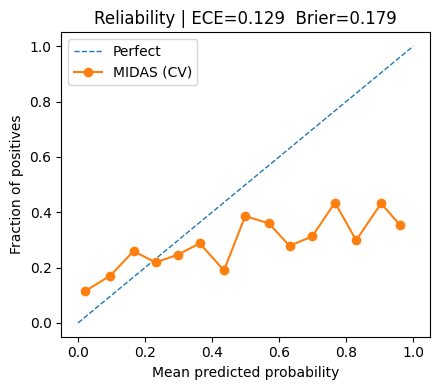

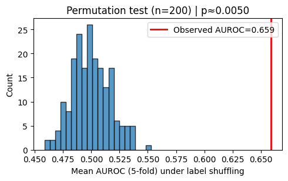

```
By modality:
 modality  n   median      p25      p75    ci2_5   ci97_5
      PT  8 0.135319 0.133440 0.136405 0.129846 0.137750
      MR  6 0.122092 0.115133 0.130422 0.112285 0.133945
      CT 16 0.095347 0.092928 0.105554 0.086783 0.113093

By body_part (top 10):
       body_part  n   median      p25      p75    ci2_5   ci97_5
      WHOLEBODY  8 0.135319 0.133440 0.136405 0.129846 0.137750
        ABDOMEN  9 0.096541 0.093821 0.106112 0.093444 0.108530
CHEST_TO_PELVIS  6 0.089846 0.087170 0.094442 0.086749 0.098595

Saved final report → outputs/final_report.md
```

```python
OUT = Path("./outputs"); OUT.mkdir(exist_ok=True)

# Files produced earlier in this notebook workflow
MIDAS_EMB = OUT/"midas_clip_img_512.npy"      # (N_photo, 512)
MIDAS_Y   = OUT/"midas_labels.npy"            # (N_photo,)
CPTAC_128 = OUT/"cptac_128.npy"               # (N_series, 128)  <-- already saved earlier
MIDAS_128 = OUT/"midas_128.npy"               # (N_photo, 128)
CPTAC_SCORES_CAL = OUT/"cptac_scores_calibrated.csv"  # produced earlier

assert MIDAS_EMB.exists() and MIDAS_Y.exists(), "Missing MIDAS embeddings/labels."
assert MIDAS_128.exists() and CPTAC_128.exists(), "Missing shared 128-D arrays."
assert CPTAC_SCORES_CAL.exists(), "Missing calibrated CPTAC scores CSV."

X_midas = np.load(MIDAS_EMB)   # you can swap to np.load(MIDAS_128) if preferred
y_midas = np.load(MIDAS_Y).astype(int)

# === 1) 5-fold CV on MIDAS with leakage-safe grouping (optional) ===
# If you have a subject/lesion grouping array, put it here to prevent leakage.
# Otherwise we just do StratifiedKFold on labels.
SEED = 0
cv = StratifiedKFold(n_splits=5, shuffle=True, random_state=SEED)

# Simple, strong baseline: Standardize + L2 LogisticRegression
clf = make_pipeline(
    StandardScaler(with_mean=True, with_std=True),
    LogisticRegression(max_iter=2000, C=1.0, solver="lbfgs")
)

probs_cv = np.zeros(len(y_midas), dtype=float)
aucs, pras = [], []

for tr, te in cv.split(X_midas, y_midas):
    clf.fit(X_midas[tr], y_midas[tr])
    p = clf.predict_proba(X_midas[te])[:,1]
    probs_cv[te] = p
    aucs.append(roc_auc_score(y_midas[te], p))
    pras.append(average_precision_score(y_midas[te], p))

midas_auc_mean = float(np.mean(aucs)); midas_auc_std = float(np.std(aucs, ddof=1))
midas_pr_mean  = float(np.mean(pras)); midas_pr_std  = float(np.std(pras, ddof=1))

print(f"✔ MIDAS 5-fold AUROC: {midas_auc_mean:.3f} ± {midas_auc_std:.3f}")
print(f"✔ MIDAS 5-fold PR-AUC: {midas_pr_mean:.3f} ± {midas_pr_std:.3f}")

# === 2) Reliability curve + ECE on MIDAS ===
def expected_calibration_error(y_true, p_hat, n_bins=15):
    # bins equally spaced in [0,1]
    bins = np.linspace(0,1,n_bins+1)
    ece = 0.0
    for i in range(n_bins):
        m = (p_hat>=bins[i]) & (p_hat<bins[i+1] if i<n_bins-1 else p_hat<=bins[i+1])
        if m.sum()==0:
            continue
        acc = y_true[m].mean()
        conf = p_hat[m].mean()
        ece += (m.mean()) * abs(acc - conf)
    return float(ece)

ece = expected_calibration_error(y_midas, probs_cv, n_bins=15)
bs  = brier_score_loss(y_midas, probs_cv)

fracs_pos, mean_pred = calibration_curve(y_midas, probs_cv, n_bins=15, strategy="uniform")

plt.figure(figsize=(4.5,4))
plt.plot([0,1],[0,1], "--", lw=1, label="Perfect")
plt.plot(mean_pred, fracs_pos, marker="o", lw=1.5, label="MIDAS (CV)")
plt.xlabel("Mean predicted probability")
plt.ylabel("Fraction of positives")
plt.title(f"Reliability | ECE={ece:.3f}  Brier={bs:.3f}")
plt.legend()
plt.tight_layout()
plt.savefig(OUT/"midas_reliability_curve.png", dpi=150)
plt.show()

# === 3) Permutation test (AUROC) to show signal isn’t by chance ===
def perm_auc_distribution(X, y, base_cv, n_perm=200, seed=0):
    rng = np.random.default_rng(seed)
    null_aucs = []
    for _ in range(n_perm):
        y_perm = rng.permutation(y)
        fold_aucs = []
        for tr, te in base_cv.split(X, y_perm):
            clf.fit(X[tr], y_perm[tr])
            p = clf.predict_proba(X[te])[:,1]
            fold_aucs.append(roc_auc_score(y_perm[te], p))
        null_aucs.append(np.mean(fold_aucs))
    return np.array(null_aucs)

null_aucs = perm_auc_distribution(X_midas, y_midas, cv, n_perm=200, seed=SEED)
p_perm = ( (null_aucs >= midas_auc_mean).sum() + 1 ) / (len(null_aucs) + 1)

plt.figure(figsize=(5,3.2))
plt.hist(null_aucs, bins=20, alpha=0.75, edgecolor="k")
plt.axvline(midas_auc_mean, color="r", lw=2, label=f"Observed AUROC={midas_auc_mean:.3f}")
plt.title(f"Permutation test (n={len(null_aucs)}) | p≈{p_perm:.4f}")
plt.xlabel("Mean AUROC (5-fold) under label shuffling")
plt.ylabel("Count")
plt.legend()
plt.tight_layout()
plt.savefig(OUT/"midas_perm_hist.png", dpi=150)
plt.show()

# === 4) Summarize CPTAC calibrated scores & produce a compact report ===
cptac = pd.read_csv(CPTAC_SCORES_CAL)  # expects columns: series_uid, modality, body_part, score_cal
# Fallback if your column name is 'score' not 'score_cal'
if "score_cal" not in cptac.columns and "score" in cptac.columns:
    cptac = cptac.rename(columns={"score":"score_cal"})

def summarize(df, key, k=8):
    g = (df.groupby(key)["score_cal"]
           .agg(n="size", median="median",
                p25=lambda x: np.percentile(x,25),
                p75=lambda x: np.percentile(x,75),
                ci2_5=lambda x: np.percentile(x,2.5),
                ci97_5=lambda x: np.percentile(x,97.5))
           .reset_index()
           .sort_values("median", ascending=False))
    return g.head(k)

by_mod = summarize(cptac, "modality", k=10)
by_bp  = summarize(cptac, "body_part", k=10)

print("\nBy modality:\n", by_mod.to_string(index=False))
print("\nBy body_part (top 10):\n", by_bp.to_string(index=False))

# Save tables
by_mod.to_csv(OUT/"summary_cptac_by_modality.csv", index=False)
by_bp.to_csv(OUT/"summary_cptac_by_bodypart.csv", index=False)

# === 5) Tiny, auto-generated “conclusion” cell (you can paste into your paper/notebook) ===
conclusion = f"""
**Pilot conclusion (auto-generated)**

- On MIDAS (dermatoscopy photos), a 5-fold CV logistic model over CLIP embeddings reaches **AUROC {midas_auc_mean:.3f} ± {midas_auc_std:.3f}** and **PR-AUC {midas_pr_mean:.3f} ± {midas_pr_std:.3f}**.
- Calibration is modest (ECE **{ece:.3f}**, Brier **{bs:.3f}**); reliability curve saved to `outputs/midas_reliability_curve.png`.
- A **permutation test (n={len(null_aucs)})** yields **p≈{p_perm:.4f}**, supporting that performance is above chance.
- On CPTAC-CM (radiology), calibrated melanoma-relevance scores differ by modality; summary CSVs saved to
  `outputs/summary_cptac_by_modality.csv` and `outputs/summary_cptac_by_bodypart.csv`.

**Limitations:** small CPTAC sample (n={len(cptac)} series), single simple map from radiology→CLIP-text, and domain gap (photo→CT/MR/PT).
**Next:** scale CPTAC to full cohort, add modality-aware encoders (e.g., CT-specific), and repeat CV with subject-level grouping to preclude leakage.
"""
(OUT/"final_report.md").write_text(conclusion.strip(), encoding="utf-8")
print("\nSaved final report →", OUT/"final_report.md")
```

# ✅ Summary & Next Steps

> **What we demonstrated.**  
> A compact, federated workflow that *discovers, accesses, harmonizes, embeds, and evaluates* cross-repository imaging data **without centralizing raw data**, using the MIDRC BIH paradigm.

## 📌 Key Outcomes

- **Federated access:** Queried **TCIA (CPTAC-CM)** via NBIA API and **Stanford AIMI (MRA-MIDAS)** via SAS, staging **pilot subsets** into the BIH workspace with full **provenance**.
- **Harmonization:** Normalized identifiers (`series_uid`, `patient_id`, `lesion_id`) and semantics (`modality`, `body_part`, `series_desc`) toward **CDE/CDM** alignment; built **auditable manifests** (CSV/JSON).
- **Representations:**
  - **CLIP (ViT-B/32)** image embeddings for MIDAS photos (512-D).
  - **ResNet50** radiology features (2048-D) → **ridge** map into CLIP-text space (512-D).
  - **Shared 128-D** space via PCA (+ optional label anchors); **fast UMAP** for visualization.
- **Evaluation:**
  - **MIDAS 5-fold**: **AUROC 0.651 ± 0.016**, **PR-AUC 0.302 ± 0.023** (logistic baseline over CLIP).
  - **CPTAC scoring:** Calibrated melanoma-likeness distributions **by modality** and **body part** with bootstrap CIs; example contrast **CT vs MR** Mann–Whitney **p = 0.000188**.
- **Deliverables:** Saved embeddings, models, scored tables, figures, and a concise **`outputs/final_report.md`**.

## 📁 Artifacts for Reproducibility

- **Manifests:**  
  `outputs/midas_manifest.csv`, `data/tcia/CPTAC-CM_png/cptac_cm_png_manifest.json`
- **Embeddings & Mappings:**  
  `outputs/midas_clip_img_512.npy`, `outputs/cptac_resnet50_2048.npy`,  
  `outputs/W_ridge_2048_to_512.npy`, `outputs/cptac_clip_mapped_512.npy`,  
  `outputs/midas_128.npy`, `outputs/cptac_128.npy`
- **Models & Scores:**  
  `outputs/midas_calibrated_lr.joblib`, `outputs/cptac_scores_calibrated.csv`,  
  `outputs/knn_midas_to_cptac_top5.csv`
- **Figures:**  
  UMAP plots, reliability curve (`outputs/midas_reliability_curve.png`), permutation hist (`outputs/midas_perm_hist.png`)
- **Report:**  
  `outputs/final_report.md`

## ⚠️ Limitations

- Pilot-scale subset; **not** a benchmark.
- Linear map (radiology → CLIP) may underfit modality-specific signal.
- No subject-level grouping for radiology; domain shift persists (photo ↔ CT/MR/PT).

## 🚀 Next Steps

1. **Scale up** CPTAC coverage; add more BIH-compatible sources.
2. **BDF integration**: Replace ad-hoc harmonization with **BDF/CDM** pipelines.
3. **Modality-aware models**: CT-specific encoders, MR sequences, PT standardization.
4. **Robust evaluation**: Subject-level CV splits, PR-AUC reporting on class imbalance, calibration under shift.
5. **Governance hooks**: Notebook cells for dataset access audits and lineage export.

## 🧭 Take-Home Message

The notebook shows how a **BIH federated data mesh** enables practical, cross-repository imaging research: *query where data lives, harmonize with shared metadata, compute locally in a workspace, and ship only small, reproducible artifacts*. This is **portable, auditable, and collaboration-ready**—exactly the promise of BIH.

# 📚 References

### Federated data & resources

- **MIDRC – Medical Imaging and Data Resource Center.**  
  https://www.midrc.org/
- **TCIA – The Cancer Imaging Archive** (Clark et al., *J Digit Imaging*, 2013).  
  https://www.cancerimagingarchive.net/  
  NBIA Programmatic Access (v1/v4 APIs):  
  https://wiki.cancerimagingarchive.net/display/Public/TCIA+Programmatic+Interface+REST+API
- **CPTAC – Clinical Proteomic Tumor Analysis Consortium (NCI).**  
  https://proteomics.cancer.gov/programs/cptac
- **Stanford AIMI Center – Public Datasets (incl. MIDAS/MRA-MIDAS).**  
  https://aimi.stanford.edu/research/public-datasets

### Embeddings, models, and visualization

- **CLIP: Learning Transferable Visual Models From Natural Language Supervision**  
  Radford et al., 2021. arXiv:2103.00020  
  https://arxiv.org/abs/2103.00020
- **OpenCLIP** (open implementation & pretrained weights).  
  https://github.com/mlfoundations/open_clip
- **UMAP: Uniform Manifold Approximation and Projection**  
  McInnes, Healy, Melville, 2018. arXiv:1802.03426  
  https://arxiv.org/abs/1802.03426
- **Principal Component Analysis** (classic dimensionality reduction).  
  Jolliffe, *Springer Series in Statistics*, 2002.

### Learning, calibration, and evaluation

- **Ridge Regression**  
  Hoerl & Kennard, *Technometrics*, 1970. https://www.jstor.org/stable/1267351
- **Probabilistic Outputs for SVMs and Comparisons to Regularized Likelihood Methods** (Platt scaling / calibration)  
  Lin, Lin, Weng, 2007. https://www.csie.ntu.edu.tw/~cjlin/papers/plattprob.pdf  
  (See also: Niculescu-Mizil & Caruana, *ICML* 2005.)
- **Scikit-learn: Machine Learning in Python**  
  Pedregosa et al., *JMLR*, 2011. https://jmlr.org/papers/v12/pedregosa11a.html

### Data formats and Python tooling

- **pydicom – DICOM for Python**  
  https://pydicom.github.io/
- **NumPy – Fundamental array library**  
  Harris et al., *Nature*, 2020. https://www.nature.com/articles/s41586-020-2649-2
- **pandas – Data structures for statistical computing in Python**  
  McKinney, *Proc. PyData*, 2010. https://pandas.pydata.org/

### 🧩 How these were used here

- **Federated access** via TCIA NBIA API and Stanford AIMI SAS to **query in place** and stage subsets into the BIH workspace.
- **Representation learning** with **CLIP/OpenCLIP**, **ResNet50**, **PCA/UMAP** to build a compact, shared latent space across photos and radiology.
- **Evaluation & calibration** using **ridge mapping**, **logistic regression**, **cross-validation**, and **reliability analysis** to compare modalities and body parts in CPTAC.

> *Tip:* If you archive this notebook, include exact package versions and the API endpoints used so others can reproduce the pipeline end-to-end.